# [2019]_Горелов_Шарпей_II

# Создание параметров пользователя

   Свойства ▾📌X textBox1 System.Windows.Forms.TextBox
- (ApplicationSettings)
  - (PropertyBinding) (...)
- (DataBindings)
  - (Name) textBox1
  - AcceptsReturn False

Рис. 12.3. Привязка свойства элемента управления textbox

4. Появится диалоговое окно «Параметры приложения» (см. рис. 12.4). В этом окне щелкните раскрывающееся меню для свойства, которое нужно привязать, и выберите команду «Создать». Мы выберем свойство `Text`.

Страница 277

```
Параметры приложения для \"ТегtВоx1\" ? X
Привязать свойства к параметрам приложения
RightToleft (нет)
Scrollßars (нет)
ShortcutsEnabled (мет)
Size (нет)
Tabindex (ner)
TabStop (нет)
Tag (нет)
Flext (нег)
TextAliqn (нет)
Для изменения параметров приложения и уп... служит конструктор проекта.
Кнопка: OK.
```

Рис. 12.4. Выбор свойства Text для привязки к параметру

Примечание. В конструкторе не будут отображены свойства, тип которых определен в текущей сборке. Это известное ограничение. Для привязки такого свойства необходимо выполнить следующие действия:

- Вместо использования конструктора создайте параметр программы программным способом. либо
- Переместите определение типа свойства в другой проект, постройте проект и добавьте ссылку на эту новую сборку в текущий проект. Свойство должно быть перечислено в окне «Параметры приложения».
5. В диалоговом окне «Новый параметр приложения» настройте параметр, указав его имя, значение по умолчанию (если допустимо) и область применения (см. рис. 12.5). Если указать область `Application` (Приложение), то это свойство будет общим для всех пользователей приложения и при выполнении его нельзя будет изменить. Если указать область `User` (Пользователь), то это свойство будет доступно для чтения и записи, и его значение может быть разным у разных пользователей.

Страница 278

```
Новый параметр приложения ? X
Создайте новый параметр приложения, заполнив ниже поля.
DefaultValue Введите Вашу фамилию
Name text1
Scope User ▾
    くApplication
    く[User]
Кнопка:OK
Кнопка:Отмена
```

Рис. 12.5. Определение параметра

Для свойств формы и её элементов управления рекомендуется использовать область `User`. Для неизменяемых переменных программы, значения которых Вы не хотите хранить в программе, — область `Application`.

6. Если параметр содержит строку подключения, установите флажок «Строка подключения» в диалоговом окне.
7. Нажмите кнопку ОК в окнах «Новый параметр приложения» и «Параметры приложения». В результате этого в классе `Settings` будет создано свойство с именем `text1` для соответствующего параметра пользователя. А в папке `Properties` под файлом `Settings.settings` появится файл `Settings.Designer.cs`.
8. Новый параметр пользователя будет связан с указанным свойством `Text` элемента `textBox1`. Связь осуществляется в классе `Form1` файла `Form1.Designer.cs` с помощью привязки свойства `textBox1.Text` к свойству параметра `text1` объекта класса `Settings`. Ниже приведен фрагмент класса `Form1`, автоматически созданный для `textBox1` (пространство `System.Windows.Forms` опущено для компактности):

Страница 279

```
// textBox1
textBox1.DataBindings.Add(new Binding("Text",
    WinApp.Properties.Settings.Default,
    "text1", true,
    DataSourceUpdateMode.OnPropertyChanged));

textBox1.Location = new System.Drawing.Point(58, 40);
textBox1.Margin = new Padding(4);
textBox1.Name = "textBox1";
textBox1.Size = new System.Drawing.Size(250, 27);
textBox1.TabIndex = 0;
textBox1.Text = WinApp.Properties.Settings.Default.text1;
```

Из приведенного фрагмента следует, что объект класса `Settings` возвращается с помощью свойства `Properties.Settings.Default`. Также мы видим, что сначала устанавливается привязка, а затем свойству `Text` присваивается значение параметра `text1`. Если привязка работает успешно, то последний оператор лишний. Поскольку мы выбираем сохраняемое свойство элемента управления в окне свойств, то тип этого свойства среде разработки известен (в нашем случае — `string`). Этот тип будет использован в классе `Settings` для приведения объекта.

9. Для управления отдельными параметрами программы используйте свойства объекта `Settings`. Для сохранения пользовательских настроек необходимо явным образом вызвать метод `Save`, унаследованный классом-оболочкой. Обычно это выполняется в обработчике событий `FormClosed` или `FormClosing` главной формы.

Страница 280

10. Повторите шаги 1–6 для свойств формы `ClientSize` и `Location` и для свойства `Checked` элементов управления `CheckBox` и `RadioButton`. Присвойте соответствующим свойствам параметров следующие имена: `size`, `loc`, `checkB1`, `checkR1` и `checkR2`.
11. Создайте коллекцию строк элемента `comboBox1`: математика, программирование, экономика, история. Однако создать параметр для коллекции строк не получится (не поддерживается простая привязка). Остается только создать параметр для свойства `Text` этого элемента управления. Присвойте параметру имя `comboText`. Значения, присваиваемые параметрам по умолчанию, можно увидеть на рис. 12.8 в окне редактора параметров.

# Создание параметров приложения

```
// label1
label1.AutoSize = true;
label1.Location = new System.Drawing.Point(54, 9);
label1.Name = "label1";
label1.Size = new System.Drawing.Size(228, 20);
label1.TabIndex = 3;
label1.Text = WinApp.Properties.Settings.Default.lab1;
```

Страница 281

13. Для того чтобы наше приложение могло работать, создадим обработчики событий `button1_Click` и `Form1_FormClosed` по примеру приведенного ниже кода из файла `Form1.cs`.

```
using System;
using System.Windows.Forms;

namespace WinApp
{
    public partial class Form1 : Form
    {
        public Form1()
        {
            InitializeComponent();
        }

        private void button1_Click(object sender, EventArgs e)
        {
            Properties.Settings.Default.Reset();
        }

        private void Form1_FormClosed(object sender, FormClosedEventArgs e)
        {
            Properties.Settings.Default.size = this.ClientSize;
            Properties.Settings.Default.Save();
        }
    }
}
```

Страница 282

```
Œ Fomm1 _OX
Финансовый университет
[Иванова]
[X] участник олимпиады
[Программирование▾]
Пол:
[ ] мужской
[X] Женский
Кнопка:Исходные мастройки
```

Рис. 12.6. Форма программы в процессе работы

Страница 282

Теперь рассмотрим, как можно изменить доступный только для чтения параметр `lab1`. Зайдем в папку `bin/Debug` нашего проекта и откроем файл `WinApp.exe.config`. Вы увидите следующие строки:

```
<?xml version="1.0" encoding="utf-8"?>
<configuration>
  <configSections>
    <sectionGroup name="userSettings" type="System.Configuration.UserSettingsGroup, System, Version=4.0.0.0, Culture=neutral, PublicKeyToken=b77a5c561934e089">
      <section name="WinApp.Properties.Settings" type="System.Configuration.ClientSettingsSection, System, Version=4.0.0.0, Culture=neutral, PublicKeyToken=b77a5c561934e089" allowExeDefinition="MachineToLocalUser" requirePermission="false" />
    </sectionGroup>
    <sectionGroup name="applicationSettings" type="System.Configuration.ApplicationSettingsGroup, System, Version=4.0.0.0, Culture=neutral, PublicKeyToken=b77a5c561934e089">
      <section name="WinApp.Properties.Settings" type="System.Configuration.ClientSettingsSection, System, Version=4.0.0.0, Culture=neutral, PublicKeyToken=b77a5c561934e089" requirePermission="false" />
    </sectionGroup>
  </configSections>
  <startup>
    <supportedRuntime version="v4.0" sku=".NETFramework,Version=v4.5.2" />
  </startup>
  <userSettings>
    <WinApp.Properties.Settings>
      <setting name="text1" serializeAs="String">
        <value>Введите фамилию</value>
      </setting>
      <setting name="checkB1" serializeAs="String">
        <value>False</value>
      </setting>
      <setting name="checkR1" serializeAs="String">
        <value>True</value>
      </setting>
      <setting name="checkR2" serializeAs="String">
        <value>False</value>
      </setting>
      <setting name="loc" serializeAs="String">
        <value>0, 19</value>
      </setting>
      <setting name="size" serializeAs="String">
        <value>510, 289</value>
      </setting>
      <setting name="comboText" serializeAs="String">
        <value>Выберите предмет</value>
      </setting>
    </WinApp.Properties.Settings>
  </userSettings>
  <applicationSettings>
    <WinApp.Properties.Settings>
      <setting name="lab1" serializeAs="String">
        <value>Финансовый университет</value>
      </setting>
    </WinApp.Properties.Settings>
  </applicationSettings>
</configuration>
```

Страница 283

Найдите элемент с именем `lab1` и измените строку "Финансовый университет" на "Высшая школа экономики":

```
<setting name="lab1" serializeAs="String">
  <value>Высшая школа экономики</value>
</setting>
```

Сохраните изменения и закройте редактор. Запустите программу: Вы увидите, что в окне отобразилось название другого вуза. Совет. В целях обеспечения безопасности не сохраняйте пароли и другую конфиденциальную информацию в параметрах, так как они доступны для чтения.

# Архитектура параметров.

Рассмотрим, как выглядит наш проект в окне обозревателя решения (см. рис. 12.7).

Страница 284

```
Обозреватель решений
⇐ ⇒ 🛖 | ⏰ ▾ ⇄ 📑 | 🔧 🎞️
Обозреватель решений - поиск (Ctri +;) 🔎▾
🧻 Решение "WinApp" (проектов: 1)
< [C#] WinApp
    < 🔧 Properties
        C# Assemblylnfo.cs
    < 📑 Resources.resx
    < ⚙️ Settings.settings
        < 📑 Settings.Designer.cs
    < 🧻 Ссылки
        < App.config
    < 🧻 Form1.cs
    < [C#] Program.cs
    < [C#] Settings.cs
```

Рис. 12.7. Окно обозревателя решения

Как следует из рис. 12.7, в папке `Properties` созданы два файла — `Settings.settings` и `Settings.Designer.cs`. Файл `Settings.settings` — это XML-файл, создаваемый при определении параметров пользователя и приложения в окне свойств. Содержимое этого файла является основой для создания класса-оболочки в файле `Settings.Designer.cs`. Двойной щелчок строки `Settings.settings` приводит к загрузке редактора параметров и отображению содержимого этого файла в графическом виде (см. рис. 12.8).

Страница 285

[output not shown]

Рис. 12.8. Окно редактора параметров

```
namespace WinApp.Properties
{
    // Этот класс позволяет обрабатывать определенные события в классе параметров:
    // Событие SettingChanging возникает перед изменением значения параметра.
    // Событие SettingsLoaded возникает после загрузки значений параметров.
    // Событие SettingsSaving возникает перед сохранением значений параметров.
    internal sealed partial class Settings
    {
        public Settings()
        {
            // Для добавления обработчиков событий для
            // сохранения и изменения параметров
            // раскомментируйте приведенные ниже строки:
            // this.SettingChanging += this.SettingChangingEventHandler;
            // this.SettingsSaving += this.SettingsSavingEventHandler;
        }

        private void SettingChangingEventHandler(object sender, System.Configuration.SettingChangingEventArgs e)
        {
            // Добавьте здесь код для обработки события SettingChanging.
        }

        private void SettingsSavingEventHandler(object sender, System.ComponentModel.CancelEventArgs e)
        {
            // Добавьте здесь код для обработки события SettingsSaving.
        }
    }
}
```

Страница 286

Как мы видим, файл `Settings.cs` — это первая часть (`partial`) класса-оболочки, доступная разработчику для внесения кода. Файл `Settings.settings` по умолчанию создается в любом проекте Windows Forms в папке `Properties`. Но если Вам потребуется еще один такой файл, то щелкните правой кнопкой строку проекта, в контекстном меню выберите пункт «Добавить», далее пункт «Создать элемент». В открывшемся окне шаблонов выберите шаблон «Файл настроек». После этого в проекте появится файл `Settings1.settings` и будет открыто окно редактора параметров. Можете создавать параметры в этом окне.

Страница 287

# Содержимое класса Settings

Для того чтобы чувствовать себя специалистом в области создания и сохранения параметров, необходимо рассмотреть сгенерированный средой Visual Studio класс-оболочку `Settings`, находящийся в файле `Settings.Designer.cs`. Основное назначение класса-оболочки — создать объект этого класса и связать каждый параметр со своим свойством. Ниже приведен текст класса-оболочки (с несущественными изменениями, улучшающими читабельность).

```
using global::System.Configuration;
using global::System. Diagnostics;
namespace WinApp.Properties
{
    [System.Runtime.CompilerServices.CompilerGeneratedAttribute())
    [System.CodeDom.Compiler.GeneratedCodeAttribute
        ("Microsoft.VisualStudio.Editors.SettingsDesigner.SettingsSingleFileGenerator", "14.0.0.0")
    ]
    internal sealed partial class Settings: ApplicationSettingsBase
    {
        private static Settings defaultInstance =
            (Settings)
            (ApplicationSettingsBase.Synchronized (new Settings()))
        ;
        public static Settings Default
        {get { return defaultinstance;})
```

Страница 288

```
        [UserScopedSettingAttribute()]
        [DebuggerNonUserCodeAttribute()]
        [DefaultSetting ValueAttribute("Введите фамилию")]
        public string text1
        {
            get
            {
                return ((string)(this["text1"]));
            }
            set
            {
                this["text1"] = value;
            }
        }
```

```
        [UserScopedSetting Attribute()]
        [DebuggerNonUserCodeAttribute()]
        [DefaultSettingValueAttribute("False")]
        public bool checkB1
        {
            get
            {
                return ((bool)(this["checkB1"]));
            }
            set
            {
                this["checkB1"] = value;
            }
        }
```

```
        [UserScopedSettingAttribute()]
        [DebuggerNonUserCodeAttribute)]
        [DefaultSetting ValueAttribute("True")]
        public bool checkR1
        {
            get
            {
                return ((bool)(this["checkR1"]));
            }
            set
            {
                this["checkR1"] = value;
            }
        }
```

```
        [UserScopedSettingAttributeO)]
        [DebuggerNonUserCodeAttribute()]
        [DefaultSetting ValueAttribute("False")]
        public bool checkR2
        {
            get
            {
                return ((bool)(this["checkR2"]));
            }
            set
            {
                this["checkR2"] = value;
            }
        }
```

Страница 289

```
        [UserScopedSettingAttribute.
        [DebuggerNonUserCodeAttribute()]
        [DefaultSettingValueAttribute("0, 19")]
        public System.Drawing.Point loc
        {
            get
            {
                return ((System.Drawing,Point)(this("loc"]));
            }
            set
            {
                this["loc"] = value;
            }
        }
```

```
        [UserScopedSettingAttribute()]
        [DebuggerNonUserCodeAttribute()]
        [DefaultSetting ValueAttribute("510, 289")]
        public System.Drawing.Size size
        {
            get
            {
                return ((System. Drawing Size) (this["size"]));
            }
            set
            {
                this["size"] = value;
            }
        }
```

```
        [UserScopedSettingAttribute()]
        [DebuggerNonUserCodeAttribute()]
        [DefaultSettingValueAttribute("Выберите предмет")]
        public string comboText
        {
            get
            {
                return ((string)(this["comboText"]));
            }
            set
            {
                this"comboText"] = value;
            }
        }
```

```
        [ApplicationScopedSettingAttribute()]
        [DebuggerNonUserCodeAttribute()]
        [DefaultSetting ValueAttribute("Финансовый университет"))
        public string lab1
        {
            get
            {
                return ((string)(this["lab1"]));
            }
        }
    }
}
```

Страница 290

Приведенный листинг показывает, что классом-оболочкой является класс Settings, наследующий от системного класса `ApplicationSettingsBase`. Оператор, следующий за определением класса, создает обьект класса `Settings` со статическим именем `defaultInstance`. А ниже следует открытое свойство `Default` для извлечения этого объекта. Таким образом, чтобы получить доступ к какому-нибудь члену класса `Settings` или класса `ApplicationSettingsBase`, например к методу `Save`, необходимо использовать следующий оператop: `Properties.Settings.Default.Save()`;

Таким же образом следует обращаться и к свойствам парамеров. Всю остальную часть класса занимают свойства параметров. Рассмотрим подробно свойство параметра `checkB1`:

[output not shown]

Страница 291

Первые три строки — это атрибуты. Атрибут `UserScopedSetting` определяет область применения параметра, то есть «пользователь». Альтернативным вариантом является атрибут `ApplicationScopedSetting`, определяющий область приложения (см. параметр `lab1`). Атрибут `DefaultSettingValueAttribute` определяет значение по умолчанию. В нашем примере — `False`. Далее следует определение свойства с аксессорами `get` и `set`. Во время выполнения программы значение выбирается из кэш-памяти и сохраняется в кэш-памяти по имени параметра с помощью индексатора класса `ApplicationSettingsBase` (точнее его базового класса `SettingsBase`). Таким образом, параметр и его свойство имеют одно и то же имя. В качестве индекса используется имя параметра. Выбираемое свойством значение преобразуется из типа `Object` в тип `bool`. Этот тип был автоматически определен из свойства `Checked` элемента управления `CheckBox`, когда в окне свойств среды Visual Studio мы выбрали `Checked` для привязки к параметру. Для параметра приложения (`lab1`) аксессор `set` отсутствует, поэтому изменение параметра невозможно. Это соответствует назначению параметров приложения.

# XML-файлы

Кроме файлов, имена которых отображаются в окне обозревателя решения, среда Visual Studio, как было описано выше, создает также XML-файл `WinApp.exe.config`. Этот файл размещается там же, где и исполняемый файл приложения (см. рис. 12.10). Его содержимое было показано выше. Если в проекте созданы параметры пользователя, то создается файл `user.config`. Как найти этот файл, также было рассмотрено выше. Содержимое файла `.config` является результатом XML-сериализации.

```
Имя
WinApp.exe
WinApp.exe.config
WinApp.pdb
WinApp.vshost.exe
WinApp.vshost.exe.config
```

Рис. 12.10. Содержимое папки bin/Debug проекта

Страница 292

Файл хранит текущие значения параметров. Для нашего приложения файл `.config` после сохранения параметров имеет следующее содержимое:

```
<?xml version="1.0" encoding="utf-8"?>
<configuration>
  <userSettings>
    <WinApp.Properties.Settings>
      <setting name="text1" serializeAs="String">
        <value>Иванова</value>
      </setting>
      <setting name="checkB1" serializeAs="String">
        <value>True</value>
      </setting>
      <setting name="checkR1" serializeAs="String">
        <value>False</value>
      </setting>
      <setting name="checkR2" serializeAs="String">
        <value>True</value>
      </setting>
    </WinApp.Properties.Settings>
  </userSettings>
</configuration>
```

Обратите внимание: в файле отсутствует параметр приложения `lab1`, так как этот параметр не может изменяться программно.

Страница 293

# Значения, используемые по умолчанию

# Класс ApplicationSettingsBase

Класс `ApplicationSettingsBase` выполняет сохранение параметров в кэш-памяти и на диске и автоматическое чтение параметров из файла в кэш-память. Класс предоставляет несколько полезных методов, свойств и событий. Приведем перечень членов класса `ApplicationSettingsBase`.

Конструкторы:

- `ApplicationSettingsBase()` — инициализирует экземпляр класса `ApplicationSettingsBase` в состояние по умолчанию.
- `ApplicationSettingsBase(IComponent)` — выполняет инициализацию нового экземпляра класса `ApplicationSettingsBase` с помощью предоставленного компонента-владельца.
- `ApplicationSettingsBase(String)` — выполняет инициализацию нового экземпляра класса `ApplicationSettingsBase` с помощью предоставленного ключа параметров для устранения неоднозначности различных экземпляров параметров класса-оболочки в одном домене приложения.
- `ApplicationSettingsBase(IComponent, String)` — выполняет инициализацию нового экземпляра класса `ApplicationSettingsBase` с помощью предоставленного компонента-владельца и ключа параметров.
- `ApplicationSettingsBase(String)` — выполняет инициализацию нового экземпляра класса `ApplicationSettingsBase` с помощью предоставленного ключа параметров для устранения неоднозначности различных экземпляров параметров класса-оболочки в одном домене приложения.
- `ApplicationSettingsBase(IComponent, String)` выполняет инициализацию экземпляра класса `ApplicationSettingsBase` с помощью предоставленного компонента-владельца и ключа параметров. Все конструкторы защищены (`protected`).

Страница 294

# Наиболее значимые методы:

- `Initialize` — инициализирует внутренние свойства, используемые объектом `SettingsBase`. (Унаследовано от `SettingsBase`.)
- `Reload` — обновляет параметры из XML-файла, то есть отменяет все сохраняемые установки, выполненные пользователем в течение сеанса, и восстанавливает состояние приложения на момент его запуска.
- `Reset` — восстанавливает умолчаемые значения параметров пользователя и приложения. Перед загрузкой данных кэш-память очищается.
- `Save` — сохраняет текущие значения свойств параметров пользователя в XML-файле. (Переопределяет `SettingsBase.Save()`.)
- `Synchronized` — (Static) предоставляет класс `SettingsBase`, являющийся синхронизированным (потокобезопасным). (Унаследовано от `SettingsBase`.)
- `Upgrade` — обновляет параметры программы, чтобы отразить недавнюю установку приложения.

# Свойства:

- `Context` — возвращает контекст параметров приложения, связанный с группой приложений. (Переопределяет `SettingsBase.Context`.)
- `IsSynchronized` — возвращает значение, указывающее на то, является ли доступ к объекту синхронизированным (потокобезопасным). (Унаследовано от `SettingsBase`.)
- `this[]` — индексатор. Возвращает или задает значение указанного свойства параметра. (Переопределяет `SettingsBase.Item[String]`.) Если параметр не найден, то возвращается `null`.
- `Properties` — возвращает коллекцию свойств параметров в классе-оболочке. (Переопределяет `SettingsBase.Properties`.)
- `PropertyValues` — возвращает коллекцию значений свойств параметров. (Переопределяет `SettingsBase.PropertyValues`.)
- `Providers` — возвращает коллекцию поставщиков параметров программы, используемую программой-оболочкой. (Переопределяет `SettingsBase.Providers`.)
- `SettingsKey` — возвращает или задает ключ параметров группы параметров программы.

Страница 295

# События:

- `PropertyChanged` — возникает после изменения с помощью `set` свойства параметра пользователя.
- `SettingChanging` — возникает перед изменением с помощью `set` свойства параметра пользователя.
- `SettingsLoaded` — происходит после извлечения параметров программы из XML-файла.
- `SettingsSaving` — возникает перед сохранением значений в XML-файле.

Рассмотрим подробнее работу индексатора (свойство `Item` в документации). Когда индексатор любого параметра в методе `get` или `set` в первый раз получает управление, он загружает значения всех параметров в кэш-память. Затем при последующих вызовах индексаторы выбирают требуемые значения из кэш-памяти.

Индексатор вызывает несколько событий, в зависимости от выполняемой операции:

- При первом извлечении свойства вызывается событие `SettingsLoaded`. Событие `SettingsLoaded` возникает только после метода `get` индексатора, выполняемого первый раз, то есть в момент загрузки параметров в кэш-память. Если параметры уже были загружены методом `set` индексатора, то событие не возникнет, пока кэш не будет очищен. После загрузки параметров в кэш-память последующие доступы используют эти значения. Методы `Reset` и `Reload` очистят все кэшированные значения, поэтому данное событие будет вызвано вновь при последующем вызове метода `get` свойства.
- После установки свойства вызывается событие `OnSettingChanging`. Если обработчик не отменяет событие, тогда устанавливается значение свойства и вызывается событие `PropertyChanged`.

Страница 296

# СОХРАНЕНИЕ СПИСКА СТРОК ЭЛЕМЕНТОВ ComboBox и ListBox

СОХРАНЕНИЕ СПИСКА СТРОК ЭЛЕМЕНТОВ `ComboBox` И `ListBox`. Усложним ранее решенную задачу: перетащим на форму кнопку с текстом "+" для добавления новой строки в элемент управления `ComboBox` и кнопку с текстом "-" для удаления текущей строки из этого элемента управления (см. рис. 12.11).

```
œ Form1 _OX
финансовый университет
[Иванов]
[X]Участники олимпиады
[Программирования▾]
Пол:
[ ]Мужской
[X]Женский
Кнопка: исходный настройки
```

Рис. 12.11. Модифицированное окно приложения.

Если список элемента управления `comboBox1` будет изменен, возникнет необходимость в сохранении списка, иначе все изменения пропадут.

Страница 297

Для сохранения списка выберем в Редакторе параметров (см. рис. 12.8) строку, помеченную символом `*`, и заменим `Settings` на `Strings`. Далее, для этого параметра раскроем список типов и выберем `StringCollection` из пространства имен `System.Collections.Specialized`. В четвертом столбце можно ввести список строк, используемых по умолчанию. В этом случае список строк элемента управления, заданный в окне свойств, будет проигнорирован. Поэтому возможны два варианта источника строк, запоминаемых в XML-файле при первом запуске программы:

1. Для параметра определяется список строк по умолчанию, и он будет запоминаться в XML-файле при первом запуске программы.
2. Список строк определяется для элемента управления `ComboBox` или `ListBox` в программе или в окне свойств. Список строк по умолчанию для параметра не задается. В XML-файле при первом запуске программы будет запоминаться список строк из `ComboBox`.

# Рассмотрим реализацию этих случаев.

Вариант 1. Для параметра вводим список строк по умолчанию в Редакторе параметров. В этом случае список строк для `ComboBox`, если он есть, будет проигнорирован. Будем использовать сложную привязку элемента управления к списку параметра, для чего перетащим компонент `BindingSource` на форму и привяжем его к параметру `Strings`. Элемент управления `ComboBox` привяжем к `BindingSource`. Новую строку добавлять в `ComboBox` нельзя, так как этот элемент управления привязан к источнику данных, поэтому будем добавлять ее в источник данных, то есть в список параметра. Для запоминания выбранной в списке `ComboBox` строки нельзя использовать создание параметра в окне свойств, так как сложная привязка `comboBox1` к источнику перекрывает простую привязку его текстового поля, то есть в свойстве `comboBox1.Text` всегда будет отображаться одна и та же строка списка. Для решения этой проблемы создадим в Редакторе параметров новый параметр с именем `comboText` типа `string` и значением по умолчанию.

Страница 298

Присвоим этот параметр свойству `comboBox1.Text` в обработчике `Form1_Load`. А перед сохранением параметров установим этот параметр в текущее значение. В целом, программа может выглядеть следующим образом:

```
using System;
using System.Windows.Forms;

namespace WindowsFormsApplication1
{
    public partial class Form1 : Form
    {
        Properties.Settings set = Properties.Settings.Default;

        public Form1()
        {
            InitializeComponent();
        }

        private void Form1_Load(object sender, EventArgs e)
        {
            bindingSource1.DataSource = set.Strings;
            comboBox1.DataSource = bindingSource1;
            comboBox1.Text = set.comboText;
        }

        private void Добавить_Click(object sender, EventArgs e)
        {
            set.Strings.Add(textBox2.Text);
            bindingSource1.ResetBindings(false);
        }

        private void Выход_Click(object sender, EventArgs e)
        {
            set.comboText = comboBox1.Text;
            set.Save();
            Close();
        }
    }
}
```

Страница 299

Сохранение списка строк элемента `ListBox` еще проще, так как не надо дополнительно сохранять текстовое поле.

**Вариант 2**. Это универсальный способ, позволяющий использовать способ 1. Так как при первом запуске программы предпочтение будет отдано списку строк параметра, то для того чтобы изначально запомнились строки списка `ComboBox`, необходимо, чтобы в Редакторе список строк по умолчанию для параметра не создавался (см. рис. 12.8). Если параметр имеет значения по умолчанию, то список `ComboBox` игнорируется, и тогда мы получаем первый вариант. Не имеет смысла задавать и значение по умолчанию для параметра `ComboText`. Если у параметра `Strings` отсутствует список или он пустой, то его заполняем строками из `ComboBox`. Здесь же запоминаем в параметре значение свойства `comboBox1.Text`. Для работы с коллекцией строк добавьте пространство имен `System.Collections.Specialized`. Далее всё остается как в первом варианте.

Страница 300

Пример программы:

```
using System;
using System.Windows.Forms;
using System.Collections.Specialized;

namespace WindowsFormsApplication1
{
    public partial class Form1 : Form
    {
        Properties.Settings set = Properties.Settings.Default;

        public Form1()
        {
            InitializeComponent();
        }
```

```
        private void Form1_Load(object sender, EventArgs e)
        {
            // Проверить: это первый запуск, то есть список параметра пустой?
            if (set.Strings == null || set.Strings.Count == 0)
            {
                // Добавить элементы из списка ComboBox в коллекцию параметра Strings, чтобы сработала привязка.
                set.Strings = new StringCollection();
                string[] arr = new string[comboBox1.Items.Count];
                comboBox1.Items.CopyTo(arr, 0);
                set.Strings.AddRange(arr);
                set.comboText = comboBox1.Text;
            }

            bindingSource1.DataSource = set.Strings;
            comboBox1.DataSource = bindingSource1;
            comboBox1.Text = set.comboText;
        }
```

```
        private void Добавить_Click(object sender, EventArgs e)
        {
            set.Strings.Add(textBox2.Text);
            bindingSource1.ResetBindings(false);
        }

        private void Выход_Click(object sender, EventArgs e)
        {
            set.comboText = comboBox1.Text;
            set.Save();
            Close();
        }
    }
}
```

Таким образом, технология параметров является удобной технологией: создается класс, который запоминает параметры в XML-файле, а при первом обращении к параметру читает этот файл, поэтому параметры можно использовать для различных целей, причем не связанных с элементами управления. Некоторые задачи выходят за рамки ограничений и для их решения необходимо знание архитектуры параметров. Для таких задач приходится вручную писать вспомогательный код. Далее рассмотрим создание класса параметров вручную, то есть без использования Visual Studio.

Страница 301

# СОЗДАНИЕ ПАРАМЕТРОВ ПРОГРАММЫ ВРУЧНУЮ

В предыдущем разделе мы выяснили, что среда Visual Studio предоставляет удобную технологию по созданию параметров приложения и параметров пользователя. Она выполняет следующие задачи:

- автоматически создает типизированный класс параметров, являющийся оболочкой системного класса `ApplicationSettingsBase`;
- включает во вторую часть класса `Form1` проекта (файл `Form1.Designer.cs`) простую привязку выбранных свойств элементов управления к ассоциированным параметрам пользователя;
- для параметров приложения в этом же файле устанавливает настройку соответствующих свойств, присваивая им значения ассоциированных параметров;
- организовывает рабочее пространство и выполняет многие другие задачи;
- создает XML-файл со значениями параметров по умолчанию.

Для решения нетипичных задач среда предоставляет файл `Settings.cs`, являющийся частью класса-оболочки, доступной разработчику. Выше мы уже использовали этот файл. Однако, если требуется более тонкое управление параметрами, можно определить собственный класс-оболочку параметров приложения. Для этого необходимо создать производный класс от `ApplicationSettingsBase`, добавить свойство, соответствующее каждому параметру, и применить специальные атрибуты к этим свойствам. Можно также использовать класс для программной привязки свойств формы и элементов управления к параметрам. Важный момент: при управлении параметрами вручную XML-файл `app.exe.config` создаваться не будет — все умолчаемые значения будут выбираться из атрибутов свойств параметров.

Страница 302

# Простое приложение с параметром

Приведем пример разработки простейшего приложения с ручным управлением параметрами.

1. Создайте форму с кнопкой для изменения фона формы. Добавьте диалоговое окно `ColorDialog` (см. рис. 12.12).

   œ Form _OX Кнопка: отобразить окно цветов

Рис. 12.12. Форма приложения.

2. Добавьте в проект новый класс и присвойте ему имя `MySettings`. В определении класса установите наследование от базового класса `ApplicationSettingsBase`:

```
sealed class MySettings : ApplicationSettingsBase
```

3. Определите в классе `MySettings` свойство для каждого требуемого параметра приложения и примените к нему атрибут `ApplicationScopedSettingAttribute` или `UserScopedSettingAttribute` в зависимости от области параметра. Мы создадим свойство `FormBackColor` для параметра пользователя со значением по умолчанию `AliceBlue`. На данном этапе код должен выглядеть следующим образом:

```
using System;
using System.Configuration;
using System.Drawing;

sealed class MySettings : ApplicationSettingsBase
{
    [UserScopedSettingAttribute]
    [DefaultSettingValueAttribute("AliceBlue")]
    public Color FormBackColor
    {
        get { return (Color)this["FormBackColor"]; }
        set { this["FormBackColor"] = value; }
    }
}
```

Страница 303

4. Создайте экземпляр `mySet` данного класса-оболочки. После создания экземпляра можно выполнить привязку к свойству — в данном случае к свойству `BackColor` формы. Сделаем это в обработчике события `Load` формы:

```
MySettings mySet = new MySettings();

private void Form1_Load(object sender, EventArgs e)
{
    this.DataBindings.Add("BackColor", mySet, "FormBackColor", true, DataSourceUpdateMode.OnPropertyChanged);
}
```

5. Создайте обработчик события `Click` для кнопки «Отобразить окно цветов». В обработчике вызовите диалоговое окно `colorDialog1` и измените цвет формы.

```
private void btnBackColor_Click(object sender, EventArgs e)
{
    if (DialogResult.OK == colorDialog1.ShowDialog())
    {
        this.BackColor = colorDialog1.Color;
    }
}
```

Страница 304

6. Так как предоставляется возможность изменения параметров во время выполнения, необходимо сохранять текущие параметры пользователя в XML-файле `user.config` при закрытии формы, иначе эти изменения будут потеряны. Создайте в окне свойств обработчик события `FormClosing` для формы:

```
private void Form1_FormClosing(object sender, FormClosingEventArgs e)
{
    mySet.Save();
}
```

На этом разработка учебного проекта закончена. При первом запуске приложения фоновый цвет окна будет выбираться из атрибута `DefaultSettingValueAttribute` и будет соответствовать цвету `Color.AliceBlue`. Если изменить цвет формы и закрыть форму, то при следующем запуске форма будет закрашена сохраненным цветом. Обратите внимание на формат конструктора `Binding`, который используется для привязки свойства формы `BackColor` к параметру. Важно, чтобы был задан последний параметр со значением `DataSourceUpdateMode.OnPropertyChanged`, иначе свойство формы `BackColor` не будет сохраняться в параметре.

# Приложение с обработкой событий SettingChanging и SettingsSaving

Приведем более сложный пример приложения с обработкой событий `SettingChanging` и `SettingsSaving`. На рис. 12.13 показано окно этого приложения со следующими элементами управления:

- кнопка с именем `btnBackColor` (используется для отображения цвета, выбираемого из диалогового окна `ColorDialog`);
- кнопка с именем `btnReload` (используется для перезагрузки параметров с помощью метода `Reload`);
- кнопка с именем `btnReset` (используется для восстановления умолчаемых значений параметров с помощью метода `Reset`);
- элемент управления `StatusStrip` c `ToolStripStatusLabel` с именем `tbStatus` (используется для отображения текущего состояния программы).

Страница 305

[output not shown]

Рис. 12.13. Форма приложения

Страница 306

```
Œ Fomm1 _OX
Кнопка: изменить цвет формы
Кнопка: binReload
Кнопка: btnReset
formlocation: (X= 380, V= 151)
```

Рис. 12.14. Окно приложения после повторного запуска

Приведем текст программы (фаил rorm1.cs).

```
using System;
using System.ComponentModel;
using System. Configuration;
using System.Drawing;
using System. Windows.Forms;
```

Страница 307

```
namespace WFApp1
{
    partial class Form1 : Form
    {
        private FormSettings mySet = new FormSetting»();
        public Form1()
        {
            InitializeComponento;
        )
        private void Form1_Load(object sender, EventArgs e)
        {
            this.FormClosing + = new FormClosingEventHandler(Form1_FormClosing);
            //Связать обработчики событий свойств параметров.
            mySet.SettingChanging +=
                new SettingChangingEventHandler(mySet_SettingChanging)
            ;
            mySet.SettingsSaving +=
                new SettingsSavingEventHandler(mySet_SettingsSaving)
            ;
```

```
            //Привязать свойства элементов управления к параметрам.
            Binding bndBackColor = new Binding(
                "BackColor"
                , mySet
                , "FormBackColor"
                , true
                , DataSourceUpdateMode.OnPropertyChanged
            );
            this.DataBindings.Add(bndBackColor):
            Binding bndLocation = new Binding(
                "Location"
                , mySet
                , "FormLocation"
                , true
                , DataSourceUpdateMode.OnPropertyChanged
            );
            this.DataBindings.Add(bndLocation);
            // Присвойте значение свойству Size, так как привязка
```

Страница 308

```
            //
            // DataBinding к Size работает не корректно.
            this.Size = mySet.FormSize;
            String savedText = mySet.FormText;
            //Так как нет значения по умолчанию для FormText.
            if (savedText |= null)
            {
                this.Text = savedText;
            }
```

```
            private void Form1_FormClosing(object sender, FormClosingEventArgs e)
            {
                // Ручная синхронизация.
                mySet.FormText = this. Text + ';
                mySet.FormSize = this.Size;
                // Сохранение параметров в файле.
                mySet.Save();
            }
            private void btnBackColor_Click(object sender, EventArgs e)
            {
                if (DialogResult.OK == colorDialog1.ShowDialog())
                    this.BackColor = colorDialog1.Color;
            }
```

```
            private void btnReset Click(obiect sender. EventArgs e)
            {
                mySet.Reset();
                this.BackColor = SystemColors.Control;
            }
            private void binReload_Click(object sender, EventArgs e)
            {
                mySet.Reload();
            )
            void mySet_SettingChanging(object sender, SettingChangingEventArgs e)
            {
                tbStatus.Text = e.SettingName +": " + e.NewValue;
            }
```

Страница 309

```
            void mySet_SettingsSaving(object sender, CancelEventArgs e)
            {
                DialogResult dr = MessageBox.Show(
                    "Сохранить текущие значения параметров приложения?"
                    , "Save Settings"
                    , MessageBoxButtons.YesNo
                );
                if (dr == DialogResult.No)
                    e.Cancel = true;
            }
        }
```

```
        // Класс параметров
        sealed class FormSettings: ApplicationSettingsBase
        {
            [UserScopedSettingAttribute()]
            public String FormText
            {
                get
                {
                    return (String)this["FormText"];
                }
                set
                {
                    this["FormText"] = value;
                }
        }
```

```
        [UserScopedSettingAttribute()]
        [DefaultSettingValueAttribute(*0, 0*))
        public Point FormLocation
        {
            get
            {
                return (Point)(this["FormLocation"]);
            }
            set
            {
                this["FormLocation*] = value;
            }
        }
        [UserScopedSettingAttribute())
        [DefaultSetting ValueAttribute("370, 260")]
        public Size Formsize
        {
            get
            {
                return (Size)this"FormSize"];
            }
            set
            {
                this["FormSize"] = value;
            }
        }
```

```
        [UserScopedSettingAttribute()]
        [DefaultSettingValue Attribute("Light")]
        public Color FormBackColor
        {
            get
            {
                return (Color) this["FormBackColor"];
            }
            set
            {
                this[«FormBackColor»] = value;
            }
        }
    }
}
```

Обратите внимание на создание объекта класса-оболочки для параметров формы:

```
private FormSettings mySet = new FormSettings();
```

Доступ к параметрам программы осуществляется через ссылку `mySet`. Запустим приложение, изменив цвет фона формы на бирюзовый и размеры/положение окна. При повторном закрытии и запуске программы сохраняются предыдущие значения свойств формы (см. рисунок 12.14).

Страница 310

# ПРОВЕРКА ПАРАМЕТРОВ ПЕРЕД ИХ СОХРАНЕНИЕМ

"Поскольку параметры программы строго типизированы, существует некоторая уверенность, что пользователи не могут назначить тому или иному параметру данные неправильного типа. Однако пользователь может присвоить параметру значение, которое находится вне допустимых границ, например, задать дату рождения в будущем." Проверить значение можно традиционными способами, однако также возможно использование метода, предложенного **технологией параметров**. Родительский класс всех классов параметров `ApplicationSettingsBase` предоставляет четыре события для поддержки проверки допустимости данных. Используемое событие зависит от времени проверки параметров:

- **SettingsLoaded**: Возникает после начальной загрузки группы свойств параметров и используется для проверки начальных значений всех свойств перед их использованием в приложении.
- **SettingChanging**: Происходит до изменения значения отдельного свойства. Используется для проверки конкретного свойства перед его изменением, позволяя немедленно уведомить пользователя о неверных данных.
- **PropertyChanged**: Возникает после изменения значения свойства и редко применяется для проверки значений, за исключением случаев необходимости асинхронной продолжительной проверки.
- **SettingsSaving**: Срабатывает перед сохранением группы свойств параметров на диск. Используется для проверки всех значений в группе перед их сохранением.

Страница 311

Как правило, в программе не требуется использовать все эти события одновременно для проверки значений — часто удается выполнить все требования проверки, обрабатывая только событие `SettingChanging`. Обработка этого события помещает весь код проверки в одном месте, а не разбрасывает его по всему проекту. Обычно при обнаружении недопустимого значения обработчик событий выполняет одно из следующих действий:

- Автоматически предоставляет значение, которое заведомо правильно, например значение по умолчанию.
- Повторно запрашивает сведения у пользователя программы.
- Для событий, возникающих до выполнения действий над параметром, таких как `SettingChanging` и `SettingsSaving`, использует аргумент `CancelEventArgs e` для отмены операции изменения свойства параметра.

Страница 312

Следующие процедуры показывают, как проверить допустимость даты рождения с помощью события `SettingChanging` или `SettingsSaving`. Процедуры были написаны в предположении, что параметры программы уже созданы; в этом примере будет выполнена проверка границ для параметра с именем `DateOfBirth`. Получите ссылку на объект параметров приложения (экземпляр класса-оболочки), выполнив один из следующих пунктов списка:

- Если параметры были созданы в визуальном режиме с помощью средств Visual Studio, можно получить объект параметров по умолчанию с помощью следующего свойства: `Properties.Settings.Default`.
- Если параметры были созданы вручную путем непосредственного наследования от класса `ApplicationSettingsBase`, экземпляр класса создается вручную, например так: `MyCustomSettings settings = new MyCustomSettings();`

Теперь к свойствам параметров можно обращаться, используя ссылку `settings`. Следующие процедуры были написаны в предположении, что объект параметров программы был получен вручную и имеет имя `settings`.

Страница 313

Чтобы проверить параметр программы перед его изменением, выполните следующие действия.

1. В обработчике события `Load` формы подпишитесь на событие `SettingChanging` для обработчика `MyCustomSettings_SettingChanging`:

```
public void Form1_Load(Object sender, EventArgs e)
{
    settings.SettingChanging += MyCustomSettings_SettingChanging;
}
```

2. Определите обработчик событий `MyCustomSettings_SettingChanging` и напишите внутри него код для выполнения проверки границ даты рождения:

```
private void MyCustomSettings_SettingChanging(Object sender, SettingChangingEventArgs e)
{
    if (e.SettingName == "DateOfBirth") // Если это DateOfBirth
    {
        DateTime newDate = (DateTime)e.NewValue;
        if (newDate.Date > DateTime.Now.Date)
        {
            e.Cancel = true; // Отменить изменение параметра.
            MessageBox.Show("Введите правильную дату рождения.");
        }
    }
}
```

Чтобы проверить группу параметров перед их сохранением, выполните следующие действия:

1. В обработчике события `Load` формы подпишитесь на событие `SettingsSaving` для обработчика `MyCustomSettings_SettingsSaving`:

```
public void Form1_Load(Object sender, EventArgs e)
{
    settings.SettingsSaving += MyCustomSettings_SettingsSaving;
}
```

2. Определите обработчик событий `MyCustomSettings_SettingsSaving` и напишите внутри него код для разрешения/запрещения изменения даты рождения:

```
private void MyCustomSettings_SettingsSaving(Object sender, SettingsSavingEventArgs e)
{
    // Здесь доступны ВСЕ параметры программы.
    if (settings.DateOfBirth > DateTime.Now.Date)
    {
        e.Cancel = true; // Отменить сохранение параметров.
    }
}
```

Разработайте программу полностью, создав форму с календарем. Реализуйте один из способов проверки параметра и сохраните параметр при завершении программы.

Страница 314

# Группы параметров — дополнительные сведения.

Если приложение имеет несколько классов-оболочек параметров, каждый класс определяет группу параметров (settings group). Каждая группа имеет следующие характеристики:

- Группа может содержать любое количество типов или параметров свойств.
- Если имя группы точно не установлено во время оформления класса-оболочки при помощи атрибута `SettingsGroupNameAttribute`, тогда имя создается автоматически.

# Пользовательские поставщики параметров.

Класс параметров по умолчанию использует поставщика параметров `LocalFileSettingsProvider`. Однако разработчик может реализовать сохранение параметров в месте, отличном от принятого, например в базе данных. Для этого разработчик должен разработать своего поставщика параметров. При желании использовать альтернативного поставщика параметров класс-оболочка или свойство должны иметь атрибут `SettingsProviderAttribute`. Подробно разработка пользовательского поставщика описана в документации Microsoft.

Страница 315

# Сериализация параметров.

Если поставщику `LocalFileSettingsProvider` требуется сохранить параметры на диск, он выполняет перечисленные ниже действия:

1. Использует отражение для проверки всех свойств, определенных для производного от `ApplicationSettingsBase` класса, выявляя свойства, примененные с атрибутами `ApplicationScopedSettingAttribute` и `UserScopedSettingAttribute`.
2. Сохраняет каждое свойство на диск. Сначала пытается вызвать метод `ConvertToString` или `ConvertFromString` связанного с типом класса `TypeConverter`. Если это не удается, использует XML-сериализацию.
3. Распределяет параметры по файлам на основании атрибута параметра.

Если реализован собственный класс параметров, атрибут `SettingsSerializeAsAttribute` можно использовать для пометки свойства как предназначенного для двоичной или пользовательской сериализации с помощью перечисления `SettingsSerializeAs`. Обязательный XML-элемент `serializedAs` задает формат, используемый для сериализации в текстовое представление. Допустимые значения:

- `string` — значение сериализуется в виде строки с помощью класса `TypeConverter`.
- `xml` — значение сериализуется с использованием сериализации XML.
- `binary` — значение сериализуется с использованием двоичной сериализации.
- `custom` — поставщик параметров имеет встроенные сведения об этом параметре для проведения сериализации и десериализации.

При использовании двоичной и пользовательской сериализации необходимо определить собственный класс параметров и использовать класс `SettingsSerializeAsAttribute` для задания двоичной или пользовательской сериализации.

Страница 316

# 12.2. Сохранение в файле с помощью StreamWriter

Ниже рассматривается простой способ сохранения и восстановления свойств формы и элементов управления в текстовом файле с помощью классов `StreamWriter` и `StreamReader` соответственно. Отличие этого способа от рассмотренной выше технологии, основанной на параметрах, заключается не только в отказе от XML-сериализации, но и в том, что для сохранения свойств параметры не используются.

# СОХРАНЕНИЕ ДАННЫХ ИНТЕРФЕЙСА В ТЕКСТОВОМ ФАЙЛЕ

Сохранение свойств формы и элементов управления связано с рядом трудностей. Во-первых, нельзя сохранить целиком элементы управления, используя XML-сериализацию, так как элементы управления содержат члены, являющиеся интерфейсами. Правда, можно создать свой класс со свойствами для запоминания сохраняемых значений, а затем сериализовать экземпляр этого класса. Но в этом случае мы пойдем по пути повторения рассмотренной выше технологии фирмы Microsoft, основанной на параметрах. Не думаю, что в нашем случае получится более удобная и проработанная технология. Поэтому мы рассмотрим более простой способ сохранения свойств формы и элементов управления в файле с помощью класса потокового вывода. В отличие от технологии параметров, разработчик сам определяет, когда необходимо прочитать файл. Поскольку свойства формы и элементов управления желательно иметь в формате, удобном для дальнейшей работы (например, для просмотра и изменения в Блокноте), будем преобразовывать сохраняемые значения в строки и записывать их в текстовый файл с помощью класса `StreamWriter`. Еще одно замечание. Если списочный элемент управления привязан к источнику данных, то будем сохранять источник, так как он не сохраняется самостоятельно, как, например, таблицы в базе данных. Для примера рассмотрим сохранение элементов `ComboBox`, `CheckBox` и `TextBox`. Пусть `ComboBox` содержит коллекцию строк типа `string`. Коллекции выделенных строк и их индексов сохранять не будем. Сохранять элементы управления будем при закрытии программы в обработчике события `Form1_Closed`. Для нашего примера создадим форму, показанную на рис. 12.15. Кнопки «+» и «-» будут использоваться для добавления новой строки в список и соответственно для удаления текущей из списка.

Страница 317

```
œ Form1 _OX
[Москва]
Автомобили:
[Мерседе▾]
    <Audi
    <Mazda
    <Ford
    <Volkswagen
    <BMV
    <Renault
[X]автовладелец
Кнопка:+
Кнопка:-
```

Рис. 12.15. Окно программы

Страница 318

Введем в обработчик `Form1_FormClosed` следующий код для сохранения значений в файле:

```
using System.IO;

private void Form1_FormClosed(object sender, FormClosedEventArgs e)
{
    // Сохранить параметры программы
    try
    {
        StreamWriter sout = new StreamWriter("Params.txt");
        // Запомнить флажок.
        sout.WriteLine(checkBox1.Checked);
        // Запомнить список.
        sout.WriteLine("**Начало списка**");
        sout.WriteLine(comboBox1.Text); // Текущая строка.
        foreach (string v in comboBox1.Items)
            sout.WriteLine(v);
        sout.WriteLine("**Конец списка**");
        // Запомнить текстовое поле.
        sout.WriteLine(textBox1.Text);
        sout.Close(); // Закрыть поток.
    }
    catch (Exception exc)
    {
        MessageBox.Show("Ошибка при сохранении параметров. \n\n" + exc.Message);
    }
}
```

Страница 319

Запустим программу, введем строку "Москва", отметим флажок, добавим в список новую марку "Mercedes", выделим строку "Ford" и удалим её. После этого закроем программу. В результате параметры будут сохранены в каталоге exe-программы в файле `Params.txt`. Если мы откроем файл `Params.txt` в Блокноте, то увидим следующее содержимое:

[output not shown]

Новая строка "Mercedes" была добавлена, а строка "Ford" — удалена. Строки "**Начало списка**" и "**Конец списка**" отмечают границы списка и позволяют пользователю вручную внести изменения. Наличие строки "**Конец списка**" дает возможность сохранять в файле произвольное количество строк списка. Обратите внимание: первое значение после строки "**Начало списка**" — это текстовое поле элемента `ComboBox`; далее следуют строки списка. Загрузка данных из текстового файла.

# ЗАГРУЗКА ДАННЫХ ИЗ ТЕКСТОВОГО ФАЙЛА

Установку элементов управления в предыдущее состояние лучше всего выполнять в обработчике `Form1_Load`. При первом запуске программы файл `Params.txt`, скорее всего, будет отсутствовать, поэтому необходимо выполнить соответствующую проверку. Код восстановления параметров приведен ниже.

Страница 320

```
private void Form1_Load(object sender, EventArgs e)
{
    try
    {
        if (File.Exists("Params.txt"))
        {
            StreamReader sin = new StreamReader("Params.txt");
            // ИНИЦИАЛИЗАЦИЯ ФОРМЫ ЗНАЧЕНИЯМИ ИЗ ФАЙЛА
            // checkBox1:
            checkBox1.Checked = bool.Parse(sin.ReadLine());
            // Заполнить список.
            sin.ReadLine(); // Пропустить "**Начало списка**"
            comboBox1.Text = sin.ReadLine();
            comboBox1.Items.Clear();
            string str;
            while ((str = sin.ReadLine()) != "**Конец списка**")
                comboBox1.Items.Add(str);
            // textBox1:
            textBox1.Text = sin.ReadLine();
            sin.Close(); // Закрыть 'читателя'
        }
    }
    catch (Exception exc)
    {
        MessageBox.Show(exc.Message + "\nОшибка чтения файла параметров. " + "Установите значения вручную.");
    }
}
```

Как видите, рассмотренный способ не является сложным и не требует дополнительных знаний, как в случае использования технологии, основанной на параметрах.

Страница 321

# 12.3. Использование системного реестра

Использование системного реестра имеет свои преимущества и недостатки. Во-первых, при перемещении программы с компьютера на компьютер системный реестр, в отличие от файла, просто так не перенесешь. Во-вторых, не рекомендуется перегружать системный реестр, так как операционная система начинает работать медленней. Однако для хранения свойств формы и элементов управления в случае использования системного реестра не требуется отдельный файл, а доступ к сохраненным значениям осуществляется по их именам. Ниже показано, как сохранить и прочитать отдельные значения, не создавая подразделов реестра. Пример с созданием подраздела приведен ниже при описании локализации интернациональных приложений.

# СОХРАНЕНИЕ ЗНАЧЕНИЙ

Приведем простейший пример сохранения в корне раздела `HKEY_CURRENT_USER` свойств `checkBox1.Checked`, `comboBox1.Items` и `textBox1.Text`. Чтобы сохранить список `Items` элемента `comboBox1`, скопируем его в массив. Для работы с системным реестром должны быть доступны пространства имен `Microsoft.Win32` и `System.Security`.

```
using System;
using Microsoft.Win32;
using System.Security;

private void Form1_FormClosed(object sender, FormClosedEventArgs e)
{
    // Сохранить параметры программы
    RegistryKey rk = Registry.CurrentUser;
    try
    {
        // Запомнить флажок.
        rk.SetValue("checkBox1", checkBox1.Checked);
        // Запомнить список.
        rk.SetValue("comboBox1Text", comboBox1.Text);
        // Создадим массив из строк списка.
        string[] strList = new string[comboBox1.Items.Count];
        comboBox1.Items.CopyTo(strList, 0);
        // Запомним массив.
        rk.SetValue("comboBox1", strList);
        // Запомнить текстовое поле.
        rk.SetValue("textBox1", textBox1.Text);
    }
    catch (Exception ex)
    {
        MessageBox.Show(
            "Ошибка записи в реестр: \n" + ex.Message, "ВНИМАНИЕ!",
            MessageBoxButtons.OK, MessageBoxIcon.Error);
    }
    rk.Close();
}
```

Страница 322

# ВОССТАНОВЛЕНИЕ ЗНАЧЕНИЙ

Приведем код для восстановления свойств элементов управления из системного реестра в обработчике `Form1_Load`:

```
private void Form1_Load(object sender, EventArgs e)
{
    RegistryKey rk = Registry.CurrentUser;
    try
    {
        object obj = rk.GetValue("checkBox1");
        if (obj == null) return; // Параметры не сохранены.
        checkBox1.Checked = bool.Parse((string)obj);
        textBox1.Text = (string)rk.GetValue("textBox1");
        comboBox1.Text = (string)rk.GetValue("comboBox1Text");
        string[] str = (string[])rk.GetValue("comboBox1");
        comboBox1.Items.Clear();
        comboBox1.Items.AddRange(str);
    }
    catch (Exception ex)
    {
        MessageBox.Show(
            "Ошибка записи в реестр: \n" + ex.Message,
            "ВНИМАНИЕ!",
            MessageBoxButtons.OK, MessageBoxIcon.Error);
    }
}
```

Признаком отсутствия сохраненных значений в реестре является возврат ссылки `null` при попытке прочитать значение по ключу.

Страница 323

# Очистка реестра.

Если возникнет необходимость удалить из системного реестра запомненные значения, то это можно сделать в программе с помощью метода `DeleteValue`.

**Пример**. Удалить ключ с именем `checkBox1`.

```
rk.DeleteValue("checkBox1", false);
```

Аналогично удаляются и остальные значения. Для работы с запомненными в реестре значениями можно воспользоваться системной утилитой `RegEdit`. На рис. 12.16 показано окно этой программы с сохраненными нами значениями.

Страница 324

```
œ Редактор реестра _OX
Файл Правка Вид Избранное Справка
[Компьютер\HKEY_CURRENT_USER]
```

- Компьютер
  - HKEY_CLASSES.ROOT
  - HKEY_CURRENT_USER
    - ApoEvents
    - Console
    - Control Panel
    - Envitonment

| Имя | Тип | Замечания |
| --- | --- | --- |
| (Œ По умолчанию) | REG_SZ | (значение не присвоено) |
| Œ checkBox1 | REG_SZ | True |
| Œ comboBox1 | REG_MULTU_SZ | Audi Manda Ford Volkswapen BVV Renault |
| Œ comboBox1Text | REG_S2 | Volkswagen |
| Œ textBox1 | REG_SZ | Тула |

Рис. 12.16. Окно системного реестра

Утилита `RegEdit` позволяет изменить и удалить сохраненные значения.

# 12.4. Внедрение данных в ехе-файл

Изменить содержимое программы, представленной exe-файлом, без перекомпиляции невозможно. Однако можно дописать данные в конец exe-файла, увеличив его размер. Реализация сохранения параметров программой в конце своего exe-файла достаточно сложный способ, поэтому материал этого раздела ориентирован на подготовленных читателей. Назовем предлагаемый способ сохранения параметров внутренним сохранением, так как программа осуществляет сохранение и чтение сохраненных параметров внутри своего exe-файла. Сложность внутреннего сохранения обусловлена тем, что программа, будучи запущенной, не может изменить свой активный exe-файл, так как он занят (используется процессом). Однако это ограничение, как будет показано ниже, можно обойти. Алгоритм записи данных в конец файла (не обязательно exe) построен на использовании метода `Seek`, осуществляющего установку указателя файла на требуемое смещение. Второй ключевой момент алгоритма — использование сигнатуры и адреса начала сохраненных данных. Сигнатура является признаком наличия в конце файла сохраненных (внедренных) данных. На рис. 12.17 показано два состояния файла: без сигнатуры (слева) и с сигнатурой (справа). На этом рисунке `Sign` — это сигнатура, которая является некоторым уникальным словом.

Страница 325

| ехе-файл | _ | exe-файл | Данные | Addr | Size |
| --- | --- | --- | --- | --- | --- |
|  |  | <- | <- | <- | <- |

Рис. 12.17. Исходный ехе-файл (слева) и ехе-файл с внедренными данными (справа)

Сигнатура, если она есть, всегда находится в самом конце файла. Наличие сигнатуры означает, что перед сигнатурой находится адрес (`Addr`) начала данных в exe-файле, а перед адресом — внедренные данные. Адрес начала внедренных данных всегда совпадает с адресом конца исходного exe-файла. Отсутствие в конце exe-файла сигнатуры свидетельствует о том, что данные в exe-файл не внедрены. Формат внедряемых данных может быть произвольным. Ниже приводится пример представления всех сохраняемых значений символьными строками. При вычислении размера строки следует учитывать, что каждый символ кодируется двумя байтами Unicode, а строка завершается символами `\r\n`. В качестве сигнатуры в программе выбрана строка `*SignaturA*`. Получается, что её длина равна 26 байтам: `(11 + 2) * 2`.

Страница 326

```
using System;
using System.Windows.Forms;
using System.IO;
using System.Text;
using System.Reflection;
using System.Diagnostics;
using System.Threading;
namespace WindowsFormsApplication1
{
    public partial class Formi: Form
    {
        string path;
        // Путь к exe-файлу.
        string pathz;
        // Путь к копии схе-файла.
        String sign = "*SignaturA*";
        // 11 * 2+4 =26 байтов.
```

Страница 327

```
        // Смещение в ЕХЕ-файле от начала файла.
        long shift = 0;
        Assembly exe;
        // Конструктор формы.
        public Form1()
        {
            exe = Assembly.GetExecutingAssembly();
            // ===Код процесса ===
            path2 = exe.Location;
            if (Path.GetFileNameWithoutExtension(path2).EndsWith("~~~"))
            {
                // Запущена копия программы.
                // Удалим "~~~~"
                path = path2.Remove(path2.Length - 7, 3);
                int n = 20;
                // 0,2 сек * 20 = 4 сек
                // 4 сек - максимальное ожидание.
```

```
                while (--n > 0)
                {
                    try
                    {
                        File.Delete(path);
                        File.Move(path2, path);
                        Close();
                        // Закроем копию программы.
                        return;
                    }
                    catch
                    {
                        Thread.Sleep(200);
                    }
                }
                MessageBox.Show("Не удалось выполнить процесс"
                    + "удаления и перемещения файла."
                );
                Close();
            }
            //...........
            path = path2;
            InitializeComponent();
        }
```

Страница 328

```
        // --- Метод чтения сигнатуры и смещения ----
        // Возвращаемое значение: смещение до параметров
        // от начала файла.
        private long ReadSign(string path)
        {
            long shiftRead = 0;
            // Открываем поток.
            using (FileStream f = new FileStream (path, FileMode.Open, FileAccess.Read))
            {
                // Теперь переходим к сигнатуре.
                // *SignaturA*\r\n=(11+2)*2=26
                f.Seek(-26, SeekOrigin.End);
                // Создаем читателя символьного потока.
                StreamReader datain = new StreamReader(f,Encoding.Unicode);
                // Читаем сигнатуру.
                string signRead = dataln.ReadLine();
                if (sian = = signRead)
                {
                    // Читаем адрес начала параметров.
                    f.Seek(-46, SeekOrigin.End); // 26 + 16+4
                    if (long. TryParse(datain.ReadLine(), out shiftRead))
                        MessageBox.Show("Ошибка в формате смещения!");
                }
                dataln.Dispose();
                return shiftRead;
            }
        }
```

Страница 329

```
        //Прочитать параметры и настроить элементы управления
        private void Form1_Load(object sender, EventArgs e)
        {
            shift = ReadSign(path);
            if (shift == 0)
            {
                //MessageBox.Show("Параметры в конец файла не записаны!");
                return;
            }
            using (FileStream f = new FileStream (path, FileMode.Open, FileAccess.Read))
            {
                // Теперь переходим к началу параметров.
                f.Seek(shift, SeekOrigin.Begin);
                StreamReader datain = new StreamReader(f,Encoding.Unicode);
                // ПРОЧИТАТЬ ПАРАМЕТРЫ ИЗ ЕХЕ-ФАЙЛА.
                // checkBox1:
                checkBox1.Checked = bool.Parse(dataIn.ReadLine());
                // Заполнить список.
                comboBox1. Text = dataIn.ReadLine();
                comboBox1.Items.Clear;
                string str;
                while ((str = dataln.ReadLine()) != "*Конец списка*")
                    comboBox1.Items.Add(str);
                // textBox1:
                textBox1.Text = dataln.ReadLine();
                //.....
                f.Flush(true);
                // Форсировать запись данных в файл.
                dataIn. Dispose();
            }
        }
```

Страница 330

```
        // Сохранить параметры программы.
        private void Form1_FormClosed (object sender, FormClosedEventArgs e)
        {
            // Создание копии текущего файла.
            path2 = path.Remove(path.Length - 4, 4) + "~~~N,exe";
            File.Copy(path, path2, true);
            File.Copy(path, path2, true);
            shift = ReadSign(path2);
            using (FileStream f = new FileStream(path2, FileMode.Open, FileAccess. Write))
            {
                if (shift ! = 0)
                f.SetLength(shift); // Отсечем старые параметры,
                f.Fush(); //так как они могут быть длиннее новых.
            }
```

```
            // Перейдем к концу файла.
            using (FileStream f = new FileStream(path2, FileMode. Open, FileAccess. Write))
            {
                shift = f.Length; // Длина файла - начало параметров.
                // Теперь переходим к концу файла.
                f.Seek(0, SeekOrigin.End);
                StreamWriter dataOut = new StreamWriter(f, Encoding Unicode);
                // ЗАПИСАТЬ ПАРАМЕТРЫ В КОНЕЦ ЕХЕ-ФАИЛА
                //---------------------------
                // Запомнить флажок.
                dataOut.WriteLine(checkBox1.Checked);
                //Запомнить список.
                dataOut.WriteLine(comboBox1.Text);
                foreach (string v in comboBox1.Items)
                    dataOut.WriteLine(v);
                dataOut.WriteLine("*Конец списка*");
                // Запомнить текстовое поле.
                dataOut. WriteLine(textBox1.Text);
                // Запишем начальный адрес параметров и сигнатуру.
                dataOut.WriteLine(shift.ToString("00000000"));
                dataOut.WriteLine(sign);
                f.Flush();
                dataOut.Dispose();
            }
```

Страница 331

```
            //
            // Запустить копию программы.
            Process. Start(path2);
        }
        // Кнопка +.
        private void Add_Click(object sender, EventArgs e)
        {
            if (comboBox1.Text != String.Empty)
                if (comboBox1.FindStringExact(comboBox1.Text) == -1)
                    comboBox1.Items.Add(comboBox1.Text);
        }
        // Кнопка "_"
        private void Del_Click(object sender, EventArgs e)
        {
            int i = comboBox1.SelectedIndex;
            if (i > -1) comboBox1.Items.RemoveAt(i);
        }
    }
}
```

Страница 332

Разработчик должен перенести в свою программу весь представленный выше код (за исключением, может быть, двух последних обработчиков), изменив только фрагменты, отмеченные рамкой. Способ преодоления ограничения, из-за которого нельзя писать в файл запущенной программы, состоит в следующем. Перед записью параметров создаем копию exe-файла с другим именем. В приведенном примере к имени exe-файла добавляется строка `"~~~"`. В конец копии записываем параметры. По идее, далее нужно исходный файл удалить, а копию переименовать, но этого выполнить не получится, так как исходный файл заблокирован процессом. Поэтому запускаем на выполнение программу (процесс 2) из файла-копии, а исходную программу (процесс 1) закрываем. Первый файл освобождается и становится доступным для удаления. Для запуска процесса используем оператор `Process.Start(path2);` где `path2` — путь к файлу-копии.

Страница 333

В конструкторе класса `Form1` анализируем, из какого файла запущена программа. Если это файл-копия, то выполняем следующие действия:

- удаляем исходный файл;
- переименовываем файл-копию в исходное имя;
- завершаем программу.

Если первый процесс не успел освободить исходный файл, то через 0,2 сек повторно предпринимается попытка выполнить перечисленные действия. Приведенная выше программа является учебной, поэтому в ней учтены не все исключительные ситуации. Так, например, на диске может не хватить свободного места для копирования файла или может произойти сбой при записи данных и т.д. В реальной программе все эти ситуации должны быть учтены.

# 12.5. Задания для самостоятельной работы

**Задача 1**. Добавьте на форму приложения следующие элементы управления: `CheckBox`, два элемента `RadioButton` и текстовое поле `TextBox`. Предусмотрите сохранение отображаемых значений этих элементов управления, используя окно свойств. В обработчике закрытия программы выполните сохранение параметров. Запустите программу и установите элементы управления в произвольные значения. Закройте программу и запустите её снова. Элементы управления должны отобразить сохраненные значения.

**Задача 2**. Добавьте на форму приложения элементы управления `ComboBox` и текстовое поле `TextBox`. Заполните список и поле данными в окне свойств. Оформите добавление новых строк в комбинированный список по кнопке `Button`. Запрограммируйте сохранение списка и текстового поля в файле при завершении программы. Запустите программу, измените текстовое поле и добавьте несколько новых строк в список. Закройте программу и запустите её снова. Элементы управления должны отобразить сохраненные значения.

Страница 334

# 13. ХРАНЕНИЕ ДАННЫХ В ВИДЕ РЕСУРСОВ

### 13.1. Понятие ресурса ТИПЫ РЕСУРСОВ И ИХ ОПИСАНИЕ

Ресурсы — это внедренные в сборку (exe- или dll-файл) тексты, изображения, звуки или другие данные. Ресурсы извлекаются и используются программой. Они доступны в любом её месте. Как правило, внедряются данные, являющиеся неизменными, например рисунок, но которые нельзя определить в программе в виде переменной языка C#. Вместо того чтобы хранить файлы с данными отдельно от программы, эти файлы можно внедрить в сборку. Такой подход повышает надежность программы и простоту доступа к данным. Для использования ресурсов необходимо знать:

1. Как организовать внедрение файла в сборку в виде ресурса.
2. Как извлечь ресурсы из сборки для их использования в программе.
3. Как получить ресурс в виде файла во время визуальной разработки в конструкторе формы, если файл отсутствует в проекте.

Для создания и редактирования ресурсов среда Visual Studio предоставляет разработчикам конструктор ресурсов. В Visual Studio ресурсы описываются в специальных файлах, имеющих расширение `resx`. Основное назначение `resx`-файла — упростить работу программиста по созданию ресурсов и доступу к их данным на этапе визуальной разработки программы.

Страница 335

Файлов `resx` в проекте может быть много, но все они подразделяются на три типа:

1. `resx`-файл формы;
2. `resx`-файл проекта;
3. `resx`-файл разработчика.

В обозревателе решений, на рисунке 13.1, файл `Resources.resx` из папки `Properties` является `resx`-файлом проекта, файл `Form1.resx` — `resx`-файлом формы `Form1`, а файл `Resource1.resx` — `resx`-файлом разработчика.

```
 Обозреватель решений
╔══════════════════════════════════════════╗
║Обозреватель решения - поиск (Ctrl+X)     ║
╚══════════════════════════════════════════╝

 Решение "WindowsFormsApplication2" (np)
├── WindowsFormsApplication2
│   ├── Properties
│   │   ├── AssemblyInfo.cs
│   │   ├── [Resources.resx]
│   │   └── Settings.settings
│   ├── References
│   ├── App.config
│   ├── Clock.png
│   ├── Form1.cs
│   ├── Form1.Designer.cs
│   ├── [Form1.resx]
│   ├── Form1
│   ├── Program.cs
│   └── [Resource1.resx]
└── (конец дерева)
```

Рис. 13.1. Три типа res-файлов

Страница 336

# RESX-ФАЙЛ ФОРМЫ

`Resx`-файл формы автоматически создается средой Visual Studio для обеспечения элементов управления ресурсами, например фоновыми изображениями, значками и т.д. Поскольку такой `resx`-файл может быть создан для каждой формы проекта, этот файл является индивидуальным для формы, то есть локальным. Ресурсы этого `resx`-файла будем называть ресурсами формы. Когда разработчик для элемента управления определяет файл с изображением, среда Visual Studio предлагает выбрать, с каким `resx`-файлом ассоциировать файл ресурса (см. рис. 13.2).

```
Выбор ресурса
╔══════════════════════════════════╗
║Контекст ресурса                  ║
║[x] Локальный ресурс               ║
║                                  ║
║[Импорт__] [Диаграмма__]          ║
║                                  ║
║[ ] Файл ресурсы проекта:           ║
║  Properties\Resources.resx       ║
║                                  ║
║**Вот:**                          ║
║                                  ║
║[Окно__]                         ║
║                                  ║
║      [  OK  ]   [ Отмена ]      ║
╚══════════════════════════════════╝
```

Рис. 13.2. Окно выбора ресурса

Если выбрать «Локальный ресурс» и импортировать файл, то для формы, например `Form1`, будет создан локальный `resx`-файл с именем `Form1.resx`. У одноязычной формы такой файл один. Если форма поддерживает несколько языков, то для каждого языка создается свой локальный `resx`-файл. В этом случае имя `resx`-файла образуется из имени формы и кода языка, например `Form1.de.resx`. Таким образом, у формы мультиязычного приложения может быть несколько локальных `resx`-файлов. Создание ресурсов мультиязычного приложения описано в следующем разделе.

Страница 337

# RESX-ФАЙЛ ПРОЕКТА

Вы можете в окне рис. 13.2 выбрать «Файл ресурсов проекта», тогда ресурс будет ассоциирован с общим для проекта файлом `Resources.resx` в папке `Properties`. У проекта только один `resx`-файл проекта. В каких случаях нужно выбирать ресурс проекта, а в каких ресурс формы? Рассмотрим это на примере файла, содержащего изображение. Если в Вашем приложении есть несколько форм, и Вы хотите использовать для них одно и то же изображение, то такой ресурс лучше всего определить как ресурс проекта (один для всех). Если Вы будете для каждой формы это изображение определять как локальный ресурс, то произойдет неоправданное дублирование одного и того же изображения. Как правило, в `resx`-файл формы включаются ресурсы, поддерживаемые средой Visual Studio и не предназначенные для их изменения разработчиком. Есть еще одно обстоятельство. Когда Вы определяете ресурс проекта, то файл с изображением копируется в папку `Resources` Вашего проекта, где он всегда будет Вам доступен. Этот файл обязан быть в проекте. По-другому обстоит дело с изображением, ассоциированным с локальным `resx`-файлом. Такое изображение внедряется в локальный `resx`-файл и в проекте в виде файла будет отсутствовать. Ниже будет рассказано, как извлечь такой ресурс в файл на этапе визуальной работы в Visual Studio. `Resx`-файл проекта в современных средах Visual Studio в папке `Properties` создается заранее. В ранних версиях Visual Studio `resx`-файл проекта изначально в папке `Properties` отсутствует и создается либо средой при первом добавлении ресурса, либо разработчиком по его инициативе. Изменять `resx`-файл проекта не рекомендуется, так как его создает и обновляет среда Visual Studio. Такой файл можно только просматривать. `Resx`-файл разработчика.

Страница 338

# RESX-ФАЙЛ РАЗРАБОТЧИКА

Разработчик может создать `resx`-файл для описания ресурсов программы, не связанных с интерфейсом. Такие ресурсы будем называть ресурсами разработчика, хотя в литературе их называют ресурсами пользователя. Для создания `resx`-файла разработчика (с произвольным именем) необходимо добавить такой файл из окна шаблонов. Для этого нужно выполнить следующие действия.

1. В меню «Проект» выберите команду «Добавить новый элемент». (Можно добавить и через контекстное меню, вызываемое щелчком правой кнопки мыши имени проекта.) В поле шаблонов выберите шаблон «Файл ресурсов».
2. В поле «Имя» введите произвольное имя файла, например `Resource1.resx` (см. рис. 13.3).
- Установленные
  - Элементы Visual C#
    - Код
    - Данные
    - Общие
    - Веб-приложения
    - Windows Forms
    - WPF
    - Отчет
    - Silverlight
    - SQL Server
    - Рабочий процесс
  - Графика

```
(Второй столбик дизайна)
[Сортировать: по умолчанию ▾] [œ] [|œ|]
[Элементы Visual C#] - 📑 Файл рессурсов
[Элементы Visual C#] - 📄 Текстовый шаблон дл временных вызовов
*[Элементы Visual C#] - 🧻 База данных, основанная на службах
[Элементы Visual C#] - ⚙️ Файл настроек
[Элементы Visual C#] - 📄 Таблица стилей
[Элементы Visual C#] - 📄 Текстовый файл
```

```
(Третий столбик дизайна столбик)
Тип: Элементы Visual C#
Пустая база данных SQL Server
для доступа к данным на основе служб
```

Рис 13.3. Добавление файлала ресурсов разработика

Файл будет добавлен в проект и автоматически откроется и конструкторе ресурсов (см. рис. 13.4).

1. Выбернте тип ресурса. Если это строка, то введите информацию в поля «Имя» и «Значение» (см. рис. 13.4).

   œ Строки ▾ œ Добавить ресурс ▾ [Х] Удалить ресурс | œ ▾ | ||Имя|Значение|Комментарий▾| |---|---|---|---| |->|сообщение 1|Сообщение на языке по умолчанию|| |*||||

Рис. 13.4. Добавление строки в редакторе ресурсов

Чтобы открыть конструктор ресурсов, можно дважды щелкнуть мышкой resx-файл разработчика. Локальные гех-файлы и resx-файл проекта можно только просматривать.

Страница 339

# 13.2. Чтение ресурсов

Для более удобного доступа к ресурсам проекта и ресурсам азработчика средой Visual Studio автоматически создается класс ресурсов со строгой типизацией. Имя этого класса совпадает с именем resx-файла. Класс содержится в файле имяRESXфайла. `Designer.cs`, например `Resource1.Designer.cs` (см. рис. 13.5). Имена свойств в классе совпадают с именами соответствующих ресурсов. Свойства являются статическими и доступны только для чтения.

**Примечание**. Для локальных `resx`-файлов (например `Form1.resx`) строго типизированные классы не создаются, так как не предполагается, что разработчику потребуется извлечение ресурсов в обход сгенерированного системой кода.

**Пример**. Извлечение ресурса `Clock` из `геsх`-файла разработчики `Resource1.resx`, и использование ресурса в качестве отображаемого рисунка злемента управления `PictureBox`.

```
pictureBox1.Image = Resource1.Clock;
```

**Пример**. Извлечение ресурса `Clock` из `resx`-файла проекта `Properties.Resources.resx`.

```
pictureBox1.Image - Properties.Resources.Clock;
```

Свойства строго типизированного класса скрывают от разработчика использование Менеджера ресурсов. Благодаря наличино свойсти исключаются ошибки программирования, связанные с неправильным определением имен ресурсов в виде строковых констант.

Страница 340

# 13.3. Связывание и внедрение

Страница 341

```
[Resourse1.resx ▾📌X] Form.resx
[œ] Изображение ▾ +📄 Добавить ресурс ▾
[Какая - то жосткая картинка]
MyAppImage
Вывод ▾📌X
<--->
Вкладки: операции; [Вывод]; Результат;  Результат;

(Второй столбик дизайна)
Обозреватель решений ▾📌X
(<-)(->)🛖(+⏰)▾🧻↺📑📄🔧(!=)
Обозреватель решений - поиск (Ctrl+f) 🔎▾
```

- (C#) Program.cs
- 📑 Resource1.resx
  - [📑Resource1.Designes.cs]

```
Свойства ▾📌X
Мухомор BitMap
🧻 (A->Z↓)|🔧
Comment
Filename: D:\Документы\Visual Studio 2013\Project\...
Persisterce  Скомпилировано во время компиляции
...
```

Рис. 13.5. Свойство `Persistence`

После внедрения содержимого файла в сборку хранение файла вместе с исполняемой программой становится ненужным.

# 13.4. Как извлечь из сборки внедренный файл

Часто бывает так, что в проекте есть внедренные ресурсы, нет их исходного файла, однако разработчику требуется этот файл. Учитывая, что изменять внедренные ресурсы непосредственно в cреде разработки `Visual Studio` нельзя, возникает вопрос, как получить файлы с этими ресурсами? Такую задачу можно решить двумя способами: **Во первых**, изменить статус ресурса; **Во вторых**, экспортировать ресурс. Исключение составляют ресурсы-строки - их изменять можно, так как они сохраняются в исходном виде.

Страница 342

# ИЗМЕНЕНИЕ СТАТУСА РЕСУРСА

Если в Вашем проекте есть внедренный ресурс, но нет соответствующего файла, то его можно восстановить. Для этого необходимо, дважды щелкнув на соответствующем `гех`-файле, войти в конструктор ресурсов, выделить требуемый ресурс и поменять у свойства `Persistence` значение «Внедрено в `.resx`» на значение «Скомпилировано во время компиляции» (см. рис. 13.5). После этого автоматически будет создана (если ранее не существовала) папка `Resources` и в нее будет скопирован файл с соответствующим ресурсом. Правда, файлу будет присвоено другое имя.

Страница 343

# ЭКСПОРТ И ИМПОРТ РЕСУРСА

- **Во первых**. Щелкните дважды `res`-файл и выберите в конструкторе нужный тип ресурса.
- **Во вторых**. Щелкните правой кнопкой мыши ресурс, который нужно экспортировать, и выберите в контекстном меню пункт «Экспорт в файл».
- **В третьих**. В диалоговом окне «Экспортировать ресурс в файл» передите к папке, в которую нужно экспортировать файл, и нажмите кнопку «Сохранить».
- **В четвертых**. Можете отредактировать файл, если это необходимо. Если у Вас есть файл с ресурсом, то его можно импортировать в `resx`-файл.

Чтобы импортировать ресурс:

- **Во первых**. Щелкните дважды гех-файл и выберите в конструкторе нужный тип ресурса.
- **Во вторых**. Щелкните правой кнопкой мыши ресурс, который нужна импортировать, и выберите в контекстном меню пункт«Импорт из файла».
- **В третьих**. В диалоговом окне найдите файл, который нужно импортировать, и щелкните «Открыть».

Страница 344

# 14. РАЗРАБОТКА МУЛЬТИЯЗЫЧНЫХ ПРИЛОЖЕНИЙ

### 14.1. Основные сведения

На российском рынке программных продуктов нередко встречаются приложения только на английском языке. К сожалению, не все пользователи владеют английским языком в достаточной степени. В таком же положении находятся и пользователи других, на англокзычных, стран. Точно так же, если российский производитель разработает приложение, имеющее пользовательский интерфейс только на русском языке, то вряд ли оно будет широко распространяться за рубежом. Для решения этой проблемы фирма `Microsoft` разработала антоматизированную технологию создания в среде `Visual Studio` приложений для международных рынков. Используя эту технологию, разработчик может создать программный продукт, в котором пользователи будут выбирать родной язык интерфейса. Кроме языка страны, также необходимо учитывать и регнональные параметры, например календарь, символ валюты и т.д. Поэтому приложение должно настраиваться не только на язык, но в на особенности региона. Прежаде чем говорить о языках и региональных параметров, необходимо дать несколько определений.

Страница 345

# ГЛОБАЛИЗАЦИЯ И ЛОКАЛИЗАЦИЯ

Для создания мультиязычных приложений используется пространство имен `System.Globalization`, которое содержит классы, определяющие сведения, относящиеся к культуре. К понятию «культура» будем относить язык, название страны, используемые календари, шаблоны форматирования дат и чисел, символ и название валюты, а также порядок сортировки строк и систему счисления (метрическая или другая). Разработка приложения для глобального рынка, включающего множество культур, называется глобализацией, а настройка приложения по месту его использования на конкретную культуру - локализацией. Локализованные приложения - это приложения, переведенные на требуемый язык. Локализация выполняется путем поиска и загрузки ресурсов, определяющих выбранную пользователем культуру. Оба этих термина можно объединить термином «интернационализация». Среда разработки `Visual Studio` позволяет создать мультиязычное приложение без использования каких-либо дополнительных программных средств вне этой среды.

# ЯЗЫК И РЕГИОНАЛЬНЫЕ ПАРАМЕТРЫ

Разные культуры используют разные форматы дат, времени и чисел, а также разные календари и т.д. Кроме того, культура определяет особенности сортировки строк. В приложениях используется специальная кодировка языков и региональных параметров. Чаще всего используется следующий формат кодировки культуры:

```
<код языка> - <код страны/региона>
```

где <код_языка> - код, как правило, из двух букв в нижнем регистре в соответствии с ISO 639-1, а «код страны/региона» код, как правило, из двух букв в верхнем регистре в соответствии с ISO 3166. Например, формат культуры для английского языка, используемого в США, - "en-US". Возможно и другое количество символов, например, для английского языка Европы, используется код "en-150". Встречаются форматы из трех групп кодов. Существует также способ кодировки, основанный на числовых идентификаторах (LCID), состоящих из четырех шестнадцатеричных цифр, например 0×1000 — русский язык, используемый в белоруссии. Языки и региональные параметры, как правило, делятся на группы по трем основным типам: **определенные**; **нейтральные**; **инвариантные**. Определенный язык и региональные параметры — это специфическая культура, связанная как с языком, так и со страной или регионом. Например, культура «de-AT» определяет немецкий язык с региональными параметрами Австрии. Следует заметить, что в некоторых регионах используется несколько языков как, например, в Испании. А на одном языке могут говорить в нескольких регионах. Примером таких языков могут быть английский, немецкий, русский и др.

Страница 346

**Текушая культура**. В интерфейсе приложения используется текущий язык и региональные параметры приложения. Это либо язык и региональные параметры по умолчанию (установленные в Панели управления `Windows`), либо язык и региональные параметры, установленные с помощью свойства `CurrentUICulture` (текущая культура пользовательского интерфейса, `UI`). Свойство `CurrentCulture` класса `Cultureinfo` определяет экземпляр текущей культуры. Язык и региональные параметры по умолчанию используются, когда не доступны локализованные ресурсы. Текущий язык и региональные параметры могут быть нейтральными или определенными. При использовании атрибута `NeutralResourcesLanguageAttribute` можно указать, как используются региональные настройки приложения будут использоваться по умолчанию.

Страница 347

**Инвариантный язык** и региональные параметры не учитывают языковых и региональных особенностей. В приложениях инвариантный язык и региональные параметры задаются пустой строкой ("") или идентификатором, соответствующим пустой строке. Свойство `InvariantCulture` класса `Cultureinfo` определяет экземпляр инвариантного языка и региональных параметров. Как правило, он связан с английским языком, но не связан ни с какой страной или регионом. Его можно использовать почти в любом методе пространства имен `System.Globalization`, для которого требуются сведения языка и региональных параметров. Если необходимо передать данные по сети на сервер для других пользователей, то лучше всего обеспечить их независимость от исходных настроек, то есть использовать инвариантную культуру.

**Пример**. Ниже показано, как получить имя текущей и инвариантной культуры.

```
using System.Globalization;
using System;
public class SamplesCultureInfo
{
    public static void Main()
    {
        Console.WriteLine("CurrentCulture - " + CultureInfo.CurrentCulture.Name);
        Console.WriteLine("InvariantCulture -" + CultureInfo.InvariantCulture.Name);
    }
}
```

Страница 348

Вывод:

- CurrentCulture - ru-RU
- InvariantCulture -

Существует иерархия языков и региональных параметров, в соответствии с которой родительский язык и региональные параметры нейтрального языка и региональных параметров является инвариантной культурой (`InvariantCulture`), а родительским языком и региональными параметрами инвариантной культуры (`InvariantCulture`) является сам инвариантный язык и региональные параметры. Родительский язык и региональные параметры содержат только те сведения, которые являются общими для дочерних языков и региональных параметров.

# РЕСУРСЫ ФОРМЫ И РЕСУРСЫ РАЗРАБОТЧИКА

Пользовательский интерфейс, требующий настройки на язык, включает две группы данных:

- **Во первых**, текст и изображения, используемые формами и элементами управления; Особенность этих данных заключается в том, что формы и элементы управления создаются средой `Visual Studio` в режиме визуального проектирования интерфейса пользователя.
- **Во вторых**, текст в диалоговых окнах, сообщениях об ошибках и в файлах приложения, изображения, выводимые методами рисования, и т.д., то есть данные, не основанные на формах и их элементах управления. Первая группа данных, зависящих от языка, в `Visual Studio` оформляется в виде так называемых ресурсов формы, или локальных ресурсов. Вторая - в виде ресурсов разработчика.

Страница 349

# ТЕКУЩИЙ ПОТОК И КУЛЬТУРЫ

Язык и региональные параметры маляются свойствами ныполняющегося потока. Для получення и устанонки используемой потоком культуры применяется класс `Thread`, находящийся в пространстве имен `System.Threading`. Поток определяет две культуры — одну для локализации ресурсов, другую для форматирования объектов, зависящих от языка и региональных параметров. Как правило, эти культуры совладают. Свойство `CurrentCulture` определяет культуру, используемую при форматировании объектов. Свойство потока `CurrentUICulture` определяет культуру, используемую для поиска ресурсов (для локализации). Для того чтобы изменить культуру, необходимо получить объект текущего потока с помощью свойства `Thread.CurrentThread`.

**Пример**. В следующих строках осуществляется смена текущих культур для пользовательского интерфейса и формирования анных. Новые культуры определяются объектами `CultureInfo`.

```
Thread.CurrentThread.CurrentUICulture = new CultureInfo("de-DE");
Thread.CurrentThread.CurrentCulture = new CultureInfo("en-GB");
```

При запуске потока язык и региональные параметры его пользовательского интерфейса изначально определяются с помощью свойства `GetUserDefaultUILanguage` в интерфейсе `Windows API`. Для изменения языка и региональных параметров пользовательского интерфейса, используемого потоком, приложение должно задать значение `Thread.CurrentUICulture` для нового языка и региональных параметров. Приведем форматы упомянутых свойств класса Thread: `public static Thread CurrentThread {get;}` — возвращает выполняющийся в данный момент поток.

Страница 350

`public CultureInfo CurrentCulture {get; set;}` - получает или залает язык и региональные параметры для текущего потока.

`public Cultureinfo CurrentUICulture {get;set;}` - получает или задает текущие язык и региональные параметры, используемые диспетчером ресурсов для поиска ресурсов, связанных с языком и региональными параметрами, во время выполнения.

Класс `Cultureinfo`, возвращаемый свойством `CurrentUICulture`, может представлять нейтральный язык и региональные параметры. Нейтральные язык и региональные параметры не должны использоваться с методами форматирования:

- `String.Format(IFormatProvider, String, Object[])`
- `DateTime.ToString(String, IFormatProvider)`
- `Convert.ToString(Char, IFormatProvider)`

Следует использовать метод CultureInfo. CreateSpecificCulture для получения определенного языка и региональных параметров или использоватьсвойство CurrentCulture.

# 14.2. Пример создания мультиязычного приложения

По умолчанию основное содержимое формы, в том числе и строки, сериализуются и сохраняются в выполнимом файле. Если решается задача создания мультиязычного (поддерживающего локализацию) приложения, необходимо свойству формы `Localizable` присвоить значение `true` (по умолчанию оно выставлено в `false`). **После этого**, все свойства формы и ее элементов управления, будут антоматически сериализоваться в ресурсы формы. Одни свойства сохраняются как строки, а другие — как объекты. **Создание мультиязычного** приложения в среде `Visual Studio` состоит из двух этапов: сначала создаются мультиязычные ресурсы формы для элементов управления, включая саму форму, а затем ресурсы разработчика, не связанные с формами и элементами управления.

Страница 351

# МУЛЬТИЯЗЫЧНЫЕ РЕСУРСЫ ФОРМЫ

### Создание ресурсов

1. Создадим новое приложение `Windows` с именем `ResourceWinForms1`.
2. Выделим форму и в окне «Свойства» присвоим свойству `Localizable` формы значение `true`. Свойство `Language` уже имеет значение «(По умолчанию)». Только при этом значении можно добавлять в форму новые элементы управления.
3. Перетащим элемент управления `Button` в форму и установим для него значение свойства `Text`, равным "Строка-ресурс" с размером `12pt`. Среда создает `гех`-файл с именем `Form1.resx` для языка и региональных параметров по умолчанию. В структуре проекта он появится под строкой `Form1.cs` (см. рис. 14.1). Этот `гех`-файл будет встроен в основную сборку, то есть в `ехе`-файл `ResourceWinForms1.exe`. Будем считать, что разработка формы для русского языка закончена (см. рис. 14.2). Перейдем к определению других языков.
4. Выделим форму и для свойства Language формы зададим значение "Английский (Австралия)".
5. Присвоим свойству `Text` кнопки значение «`String-resource`». Среда создаст `resx`-файл `Form1.en-AU.resx` для английского языка в Австралии.

Страница 352

6. Выделим форму и для свойства Language формы зададим значение "Немецкий"
7. Присвоим свойству `Text` новое значение - "`Zeichenfolgenressource`". При необходимости можно изменить размер кнопки для вмещения более длинной строки. Среда создаст `гех`-файл `Form1.de.resx` (код де определяет нейтральный немецкий язык).
8. Выделим форму и для свойства `Language` формы зададим значение "Немецкий (Австрия)".
9. Присвоим свойству `Text` новое значение "`String-Ressource`". При необходимости можно изменить размер кнопки для вмещения более длинной строки.

Среда создаст `resx`-файл `Form1.de-AT.resx` для немецкого языка региона Австрия, где `de` определяет немецкий язык, а `АТ` — регион Австрия. На рис. 14.1 показана структура проекта с файлами ресурсов формы (ресурсы выделены). Созданные `resx`-файлы — о файлы ресурсов для соответствующего языка и регитальных параметров. Файл `Form1.de.resx` — это файл ресурсов для нейтрального немецкого языка. `Form1.de-A.resx` — это файл ресурсов для варианта немецкого языка, принятого в Австрии. `Form1.en-AU.resx` — файл ресурсов для варианта английского языка, принятого в Австралии. Файл `Form1.resx` — файл ресурсов для языка по умолчанию. В данном примере — это русский язык. Все `resx`-файлы содержат текст на соответствующем языке, присвоенный свойству Text кнопки.

🧻 Решение "ResourceWinForms1" (выбранный один проект)

- (C#) ResourceWinForms1
  - 🔧Properties
  - ⇄ Ссылки 🧻🔧 App.config
  - 📄 Form1.cs
    - ->📄 Form.de-AT.rest
    - ->📄 Form.de.rest
    - ->📄 Form1.Designer.cs
    - ->📄 Form1.rn-Atl.cs
    - ->📄 Form1.resx
    - 🎞️ Form1

Рис. 14.1. Проект с файлами ресурсов формы

10. Построим решение.
11. Нажмём кнопку «Показать все файлы» в Обозревателе решений. В папке (`bin\Debug` отобразятся папки `de`, `de-AT` и `en-AU`, в которых будут созданы вспомогательные сборки с одинаковым именем `ResourceWinForms1.resources.dll`.

Каждая вспомогательная сборка (`dll`-файл) в мультиязычном приложении определяет набор ресурсов формы для культуры, соответствующей имени папки. В нашем приложении эти сборки состоят только из одного строкового ресурса. Ресурсы для языка по умолчанию встраиваются в основную сборку, то есть в eхе-файл, поэтому для них подкаталог не создается. Основная сборка «не знаст» о существовании вспомогательных и осуществляст их поиск, если пользователь определит соответствующую культуру. Если папка с именем, соответствующим требуемой культуре обнаруживается, то ресурсы считываются из её `dll`-файла и используются для настройки интерфейса.

12. Нажмём клавишу F5 или выберем в меню «Отладка» команду «Запуск». Появится окно с кнопкой на русском языке (см. рис. 14.2).

```
œ Form1 _OX
Кнопка: строка – ресурс
```

Рис. 14.2. Главное окно программы

Страница 353

# Смена языка интерфейса (локализация)

Приложение загружает соответствующие локализованные ресурсы на основе значения свойства `CultureInfo.CurrentUICulture`. Это значение устанавливается либо явным образом в коде приложения, либо с помощью общей среды исполнения, исходя из языковых настроек текущего пользователя на локальном компьютере.

1. В редакторе кода определите два дополнительных пространства имен:

```
using System.Globalization;
using System.Threading;
```

2. Перейдем к нейтральной немецкой культуре, для чего до вызова функции `InitializeComponent` добавим следующий код в конструктор класса `Form1`:

```
// Установить UI культуры для немецкого языка.
Thread.CurrentThread.CurrentUICulture = new CultureInfo("de");
Thread.CurrentThread.CurrentCulture = new CultureInfo("de");
```

Страница 354

3. Выполним приложение (F5). Появится окно с кнопкой на немецком языке.
4. Переход к английским ресурсам для Австралии выполняется аналогичным образом:

```
// Установить UI культуры для английского языка (Австралия).
Thread.CurrentThread.CurrentUICulture = new CultureInfo("en-AU");
Thread.CurrentThread.CurrentCulture = new CultureInfo("en-AU"):
```

5. Выполним приложение. Появится окно с кнопкой на английском языке.
6. Для перехода на русский язык зададим пустую строку для интерфейса и строку "ru-RU" для форматирования данных:

```
// Установить культуру по умолчанию
// (русский язык для России),
Thread.CurrentThread.CurrentUlCulture = new CultureInfo("").
Thread. CurrentThread.CurrentCulture = new Cultureinfo("ru-RU").
```

Страница 355

Настройка интерфейса пользователя на извлеченные ре- сурсы языка осуществляется и результате выполнения специ- ального метода, включенного средой Visual Studio для формы и каждого элемента управления в файл Formi.Designer.cs. Этим методом является метод ApplyResources менеджера ресурсов ComponentResourceManager.

# МУЛЬТИЯЗЫЧНЫЕ РЕСУРСЫ РАЗРАБОТЧИКА

### Создание ресурсов

Выше мы рассмотрели, как добавляются и читаются ресурсы для элементов управления мультиязычного приложения. Этот процесс очень хорошо автоматизирован и не требует вмешательства разработчика. А как быть с ресурсами, не связанными со свойствами элементов управления и формы, например с сообщениями, отображаемыми диалоговым окном MessageBox, или со строками, выводимыми в файл или на экран? **Существует несколько способов** решения этой проблемы, из которых рекомендуемым является следующий. Для культуры по умолчанию разработчик добавляет в проект `res`-файл разработчика и определяет в нем имена и значения ресурсов. Для каждой другой культуры разработчик также добавляет `resx`-файл с именем, соответствующим этой культуре, и прописывает в файле те же строки, что и для `resx`-файла по умолчанию, но на выбранном языке. Имена строк не изменяются. **Особенность этого способа** состоит в том, что все `resx`-файлы - разработчика и формы — с совпадающими культурами транслируются в один `dll`-файл, то есть в одну вспомогательную сборку. В проекте также создается специальный класс ресурсов разработчика со строгой типизацией, и этот класс автоматически настраивается на выбранную культуру (`dll`-файл). Класс ресурсов позволяст разработчику получить требуемую строку на выбранном языке.

Страница 356

1. В меню «Проект» выберем команду «Добавить новый элемент». Можно добавить и через контекстное меню, вызываемое щелчком правой кнопки мыши на имени проекта.
2. В поле шаблонов выберем шаблон «Файл ресурсов». В поле «Имя» введем имя файла `ProjectResource.resx` (см. рис. 14.3). Файл `ProjectResource.resx` будет содержать ресурсы на языке по умолчанию, то есть в нашем случае на русском языке. Файл будет добавлен в проект и автоматически откроется в конструкторе ресурсов.

[figure not shown]

Рис. 14.3. Добавление файла ресурсов разработчика

œ стройки▾ 📑добавить ресурс▾ 📑редактировать файл▾|📑▾|

|  | Имя | Значение | Комментарий▾ |
| --- | --- | --- | --- |
| -> | сообщение один | Сообщение на языке по умолчанию |  |
| œ | --- | --- | --- |

Рис. 14.4. Добавление строки в редакторе ресурсов

Страница 357

4. В меню Файл выберем «Сохранить `ProjectResource.resx`» Можно сохранить файл, закрывая конструктор ресурсов.
5. Выполним действия 1-4 еще четыре раза, чтобы создать новые `resx`-файлы разработчика с именами `ProjectResource.de.resx`, `ProjectResource.de-AT.resx`, `ProjectResource.en-AU.resx` и `ProjectResource.fr-FR.resx` соответственно для языков: немецкого нейтрального, немецкого для Австрии, английского для Австралии и французского для Франции.

Сообщения добавим на соответствующем языке. Для всех языков имя ресурса должно быть одним и тем же (в нашем примере «сообщение1»), а значения — разными. Для английского языка введем «`The message in English for Australia`», а для немецких - «`Die Meldung in deutscher Sprache`» и «`Beitrag in deutscher Sprache für Österreich`». Для французского — «`Message en français pour la France`». В результате этих действий в проект будут добавлены перечисленные `resx`-файлы, а для `resx`-файла языка по умолчанию будет создан файл `ProjectResource.Designer.cs` с классом со строгой типизацией ресурса (см. рис. 14.5).

Страница 358

# 6. Соберём решение

```
Обозреватель решений ▾📌X
(<-)(->)🛖(+⏰)▾🧻↺📑📄🔧(!=)
Обозреватель решений - поиск (Ctrl+f) 🔎▾
```

- (C#) ResourceWinForm1
  - 🔧 Properties
  - 🧻 🧻 Ссылки
    - 📄🔧 App.config
  - 📄 Form1.cs
    - 📄 Form1.de-AT.resx
    - 📄 Form1.de.resx
    - 📄 Form1.Designer.cs
    - 📄 Form1.en-AU.resx
    - 📄 Form1.resx
    - 📄 Form1
  - (C#) Program.cs
    - 📄 ProjectResource.de-AT.resx
    - 📄 ProjectResource.de.resx
    - 📄 ProjectResource.en-AU.resx
    - 📄 ProjectResource.fr-FR.resx
  - 📄 ProjectResource.resx
    - 📄 ProjectResource.Designer.cs

Рис. 14.5. `Resx`-файлы разработчика и класс со строгой типизацией

Таким образом, в результате выполнения вышеперечисленных шагов для выбранных культур будут созданы `dll`-библиотеки (вспомогательные сборки) с локальными ресурсами формы и ресурсами разработчика. В частности, файл `ProjectResource.resx` будет преобразован в файл `ProjectResource.resources` и внедрен в основную сборку `ResourceWinForms1.еxе`. Файл `ProjectResource.de.resx` будет преобразован в файл `ProjectResource.de.resources` и внедрен во вспомогательную сборку `ResourceWinForms1.resources.dll`, находящуюся в папке `de`. Точно также и файлы `ProjectResource.de-AT.resx` и `ProjectResource.en-AU.resx` будут преобразованы соответственно в файлы `ProjectResource.de-AT.resources` и `ProjectResource.en-AU.resources` и внедрены во вспомогательные сборки соответствующих папок. Для французского ресурса будет создан файл `ProjectResource.fr-FR.resources`, новая папка `fr-FR` и вспомогательная сборка (см. рис. 14.6).

Страница 359

- Имя
- 📄 de
- 📄 de-AT
- 📄 en-AU
- 📄 fr-FR
- 🧻 ResourceWinForms1.exe
- 🧻 ResourceWinForms1.exe.config

Рис. 14.6. Структура каталога bin debug

Следует заметить, если локальный `res`-фаил формы для соответствующей культуры отсутствует, то будет создана вспомогательная сборка только для `resx`-файла разработчика (см. французский язык).

# Доступ к ресурсам разработчика

Для чтения текущего ресурса разработчика будем использовать класс со строгой типизацией.

1. В редакторе кода импортируем пространства имен:

```
using System.Resources;
using System. Globalization;
using System.Threading;
```

Страница 360

2. Дважды нажмём кнопку, чтобы отобразить код для обработчика события `Сlick`, и добавим следующий код: `MessageBox.Show(ProjectResource.сообщение1);` где `ProjectResource` - это строго типизированный класс ресурсов разработчика, находящийся в файле `ProjectResource.Designer.cs`. `Cообщение1` - это имя сообщения, выбранного из ресурсов, и оформленного в виде свойства класса. Сообщение будет представлено на языке, который задан по умолчанию или определен свойством `CurrentUlCulture`. Если не хотите использовать строго типизированный класс, то можете использовать менеджер ресурсов в явном виде:

```
ResourceManager rm =
    new ResourceManager(
        "ResourceWinForms1.ProjectResource"
        ,typeof(Form1).Assembly
    )
;
MessageBox.Show(rm.GetString("сообщение1"));
```

3. Соберём решение и запустим программу. Щелкнем кнопку. В окне сообщения появится строка, соответствующая установленному языку и региональным параметрам интерфейса (в нашем случае русскому языку).
4. Сменим культуру пользовательского интерфейса, вставив перед вызовом метода `InitializeComponent();` оператор `Thread.CurrentThread.CurrentUICulture = new Cultureinfo ("en-AU");`
5. Выполним построение и запустим программу. Щелкнем кнопку. Вы увидите сообщение на английском языко для Австралии (см. рис. 14.7). Если свойство `CurrentUlCulture` не задано явно в коде приложения, то оно задается по умолчанию в начале работы приложения.

Страница 361

```
Œ Form 1 _OX
String resource
Œ X
The message in English for Australia
Кнопка:OK
```

Рис. 14.7. Форма и окно сообщения на английском языкс для Австралии

Следует заметить, что при объединении файлов ресурсов в один `eхе`- или `dll`-файл, корневые имена файлов локальных ресурсов и разработчика - разные. В первом случае — это `ResourceWinForms1.Form1` а во втором - `RespurceWinForms1.ProjectResource` то есть имена файлов, объединяющих ресурсы, сохраняются в интерфейсе. Все `dll-файлы` ресурсов имеют одинаковые имена, формируемые следующим образом: `ИмяПриложения.resources.dll`, например `Мультиязычное.resources.dll`.

# Поиск ресурсов

Если ресурсы для заданной культуры не обнаруживаются, система пытается использовать ресурсы нейтральной культуры Например, если ресурсы для культуры `en-AU` не заданы, система осуществляет поиск ресурсов для языка `еп`. Сборка ресурсов нейтральной культуры называется родительской. Если ресурсы для языка `еп` также отсутствуют, используются ресурсы культуры по умалчанию (в нашем случас, русской).

Страница 362

Не все свойства формы и элементов управления дублируются во вспомогательных сборках. Например, если координаты элементов управления для какой-либо культуры остались без изменения, то в соответствующей вспомогательной сборке эти координаты не сохраняются. Финансовые или временные ограничения могут не позволить создать набор ресурсов для каждого региона. В такой ситуации можно разработать единственную вспомогательную сборку для родительского (нейтрального) языка, которая будет использоваться для всех регионов, связанных с языком. Например, можно создать одну вспомогательную сборку для английского языка (`en`), которая будет вызываться пользователями при запросе англоязычных ресурсов для конкретного региона, и одну сборку на немецком (`de`) для пользователей, запрашивающих ресурсы немецкоязычной версии для определенного региона. В этом случае запросы ресурсов для немецкоязычной версии Германии (`de-DE`), немецкоязычной версии Австрии (`de-AT`) и немецкоязычной версии Швейцарии (`de-CH`) будут переданы во вспомогательную сборку для немецкого языка (`de`). Таким образом, если осуществляется разработка ресурсов для одного языка, но разных регионов, рекомендуется, по возможности, все одинаковые ресурсы локализовать в нейтральной сборке.

# Использование класса строго типизированного ресурса

Для более удобного доступа к ресурсам разработчика системой автоматически создается класс ресурсов со строгой типизацией. Класс содержится в файле `имяФайла.Designer.cs`, например `ProjectResource.Designer.cs` для ресурсов разработчика (см. рис. 14.5). Имя этого класса совпадает с именем `resx`-файла! В нашем случае это `ProjectResource`. Класс инкапсулирует набор свойств, имена которых совпадают с именами соответствующих ресурсов. Свойства являются статическими и доступны только для чтения. Они позволяют извлекать как связанные, так и внедренные ресурсы. Выше мы рассмотрели пример использования класса для получения строки с именем «сообщение 1».

**Пример.** Извлечение ресурса `Clock` из `resx`-файла `Resource1.resx` и использование ресурса в качестве отображаемого рисунка элемента управления `PictureBox`.

```
pictureBox1.Image = Resource1.Clock; // Ресурс разработчика
```

Для локальных `resx`-файлов, например `Form1.resx`, строго типизированные классы не создаются, так как разработчик не должен вмешиваться в работу сгенерированного системой кода.

Страница 363

# ЛОКАЛИЗАЦИЯ ПРИЛОЖЕНИЯ

Локализация приложения заключается в настройке приложения по месту его использования, то есть в выборе пользователем требуемой культуры и настройке приложения на эту культуру. Существует несколько способов локализации.

# Смена языка с помощью меню

Ниже рассматривается способ представления пункта меню в виде списка `ComboBox`, содержащего доступные приложению культуры. Особенность способа заключается в том, что список формируется динамически на основе имен каталогов текущей папки, содержащих вспомогательные сборки с ресурсами культуры. Текущая культура запоминается в подразделе `Language` подраздела текущего пользователя `CurrentUser` системного реестра. Меню представляется либо на языке по умолчанию (русском), либо на английском в зависимости от того, запомнен ли русский язык в реестре или нет. Представление списка меню на языках других доступных культур выполняется аналогично, но из-за большого объема работы здесь не рассматривается. Главное окно программы и раскрытый список культур представлен на рис. 14.8. Список имеет имя `Languages`. Из рисунка следует, что каждая строка списка меню содержит полное наименование культуры и код этой культуры. Если каталог какой-либо вспомогательной сборки будет удален или добавлен новый, то список также изменится. При этом перекомпилировать программу не нужно.

Страница 364

```
Œ Form1 _OX
 Available languages ▾
Кнопка: Строка-ресурс

吧 Formt _OX
Avallable language:▾
```

- Русский (Россия) : ru-RU
- Немецкий (Германия): de-DE
- Немецкий (Австрия) : de-AT
- Английский (США) : en-US
- Английский (Австралия) : en-AU
- Французский (Франция) : fr-FR

Рис. 14.8. Главное окно программы (слева) и его раскрытое меню (справа)

Ниже приведен листинг программы, реализующей рассматриваемый способ.

```
using System;
using System.Windows.Forms;
using System.Globalization;
using System.Threading;
using System.Resources;
using Microsoft.Win32;
using System.IO;
using System.Collections.Generic;
```

Cтраница 365

[output not shown]

Страница 366

[output not shown]

Страница 367

```
        //---- Кнопка
        private void button1_Click(object sender, EventArgs e)
        { MessageBox.Show(ResourceWinForms1.ProjectResource.сообщение1); }
        // Выборка языка из списка и установка нового языка.
        private void Languages_TextChanged(object sender,
        {
            string citCur = Thread.CurrentThread.CurrentUlCulture.Name;
            string[] sep = {" : " };
            string[] names = Languages. Text. Split(sep, StringSplitOptions.RemoveEmptyEntries);
            if (names.Length == 2 && names[1] != cltCur)
            {
                this.Controls.Clear);
                // Установить UI новой культуры.
                Thread.CurrentThread.CurrentUICulture = new Cultureinfo(names[1]);
                Thread.CurrentThread.CurrentCulture = new Culturelnfo(names[1]);
                InitializeComponent();
                // Создать список.
                Languages.Items.AddRange(items.ToArray());
            }
        }
```

Страница 368

```
        // Если был установлен новый язык, то запоминаем его в реестре.
        private void Form1_FormClosed (object sender, FormClosedEventArgs e)
        {
            string cultureNew = Thread.CurrentThread.CurrentUlCulture.Name;
            if (cultureCur l= cultureNew)
            {
                subkey = cUser.CreateSubKey ("Language");
                // Создать данные для подраздела "Параметры теста"
                subKey.SetValue("culture", cultureNew);
                subKey.Close();
            }
        }
    }
}
```

Поскольку инициализация формы и ее элементов управления осуществляется в конструкторе Form1, который выполняется один раз, то при смене языка необходимо контейнер формы очистить и после установки нового языка выполнить инициализацию еще раз. **Для работы** с системным реестром в программу необходимо добавить пространство имен `Microsoft.Win32` . Конструктор формы изменен для считывания культуры из реестра. Для запоминания новой культуры в реестре добавлен обработчик события `FormClosed`. Если при завершении программы фиксируется смена языка, то обработчик события `FormClosed` создает дочерний узел `Language` и запоминает в нем новую культуру под именем `culture`. При следующем запуске программы значение культуры будет считано из подраздела и установлено в качестве текущей.

**В приведенном примере** для создания объекта для работы с подразделами ключа `CurrentUser` используется оператор

```
RegistryKey User; cUser = Registry.CurrentUser;
```

Метод `OpenSubKey` этого объекта открывает в реестре подраздел, метод `CreateSubKey` создает подраздел, метод `SetValue` записывает в подраздел значение заданного ключа, а метод `GetValue` читает значение для заданного ключа из подраздела. **Если потребуется удалить подраздел**, то можно воспользоваться таким фрагментом кода:

```
Registry cUser = Registry.CurrentUser;
subKey = cUser.OpenSubKey ("Language", true);
subKey.DeleteSubKey("");
subKey.Close();
```

Страница 369

Текущий каталог приложения представлен на рис. 14.9. Из рисунка следует, что приложение, кромс культуры по умолчанию, использует культуры: `de`, `de-AT`, `en`, `en-AU` и `fr-FR`.

- 🧻 de
- 🧻 de-AT
- 🧻 en
- 🧻 en-AU
- 🧻 fr-FR
- 🧻 Не подходящая папка
- 🧻 ResourceWinForms1.exe
- 🧻 ResourceWinForms1.exe.config
- 🧻 ResourceWinForms1.pdb
- 🧻 ResourceWinForms1.vshost.exe
- 🧻 ResourceWinForms1.vshost.exe.config
- 🧻 ResourceWinForms1.vshost.exe.manifest

Рис. 14.9. Состав текущего каталога

Для создания списка каталогов текущей папки и выделения имени каталога из пути используются классы `Directory` и `Path` пространства имен `System.IO`. Поскольку в текущей папке могут оказаться каталоги, не относящиеся к какой-либо культуре (на рис. 14.9 — «Неподходящая папка»), то обработка таких каталогов порождает исключение. Обработка исключения сводится к переходу к следующему каталогу списка. Строка для культуры по умолчанию не связана с каталогом, поэтому она добавляется в список меню отдельно.

Страница 370

# Другие способы смены языка

Часто язык и региональные параметры устанавливаются пользователем во время инсталляции программы в одном из окон. Сделанный выбор можно запомнить в реестре или в файле, уникальном для текущего пользователя. Если смена языка во время выполнения программы не предполагается, то лишние вспомогательные сборки в развертываемое приложение можно не включать. **Нередко приложение** поставляется уже настроенным на конкретный язык, и в процессе инсталляции выбор языка интерфейса пользователю не предлагается. Такое приложение, как правило, имеет всего одну вспомогательную сборку. Сохранение кода выбранной культуры в реестре было рассмотрено выше. Здесь же покажем, как для этой цели использовать параметр системной технологии сохранения настроек программы (см. раздел 12.1). Следует сразу же отметить, что использовать параметр целесообразно даже в том случае, если эта технология не применяется в программе по прямому назначению. Целесообразность этого решения состоит в том, что вопросы сериализации и десериализации параметров возлагает на себя система. И самое главное: для каждого пользователя компьютера (то есть для каждой учетной записи) создается свой уникальный XML-файл. **Щелкните левой кнопкой файл** `Settings.Settings` в разделе `Properties` обозревателя решений. Откроется окно Редактора параметров. Создайте параметр с именем `language` типа `string`. По умолчанию у параметра рекомендуется установить значение `"ru-RU"`. В этом случае из ресурсов будет выбираться значение для языка по умолчанию, так как соответствующий dll-файл найден не будет, а для форматирования данных будет использоваться культура «русский язык для России». Можно выполнить проверку: если текущая культура потока равна `""`, то для форматирования данных использовать код `"ru-RU"`.

Страница 371

Установите перед инициализацией компонентов исходную (при первом запуске) или запомненную культуру в качестве текущей с помощью следующего оператора:

```
Thread.CurrentThread.CurrentUICulture =  new CultureInfo(Properties.Settings.Default.language);
```

При завершении программы запомните код текущей культуры в параметре:

```
Properties.Settings.Default.language = Thread.CurrentThread.CurrentUICulture.ToString();
```

Полный текст программы для трех языков, перечисленных в списке меню, представлен ниже. В программе для упрощения текста объект класса `Settings` запоминается в переменной `set`.

```
using System;
using System.ComponentModel;
using System.Globalization;
using System.Threading;
using System.Windows.Forms;
```

```
namespace MultiLangSave
{
    public partial class Form1 : Form
    {
        Properties.Settings set = Properties.Settings.Default;

        public Form1()
        {
            Thread.CurrentThread.CurrentUICulture = new CultureInfo(set.language);
            Thread.CurrentThread.CurrentCulture = new CultureInfo(set.language);
            InitializeComponent();
        }

        private void SaveExit_Click(object sender, EventArgs e)
        {
            set.language = Thread.CurrentThread.CurrentUICulture.ToString();
            set.Save();
        }

        private void русскийToolStripMenuItem_Click(object sender, EventArgs e)
        {
            Thread.CurrentThread.CurrentUICulture = new CultureInfo("ru-RU");
            Thread.CurrentThread.CurrentCulture = new CultureInfo("ru-RU");
            Controls.Clear();
            InitializeComponent();
        }
```

Страница 372

```
        private void английскийToolStripMenuItem_Click(object sender, EventArgs e)
        {
            Thread.CurrentThread.CurrentUICulture = new CultureInfo("en-US");
            Thread.CurrentThread.CurrentCulture = new CultureInfo("en-US");
            Controls.Clear();
            InitializeComponent();
        }

        private void немецкийToolStripMenuItem_Click(object sender, EventArgs e)
        {
            Thread.CurrentThread.CurrentUICulture = new CultureInfo("de-DE");
            Thread.CurrentThread.CurrentCulture = new CultureInfo("de-DE");
            Controls.Clear();
            InitializeComponent();
        }
    }
}
```

Примечание. Не следует привязывать к параметру свойство элемента управления, запоминаемое как ресурс разных культур — всегда будет отображаться последнее запомненное в параметре значение. Дело в том, что в файле `Form1.Designer.cs` сначала считываются ресурсы элемента управления, а затем выполняется простая привязка свойства элемента к параметру, которая и отменяет ресурсное значение.

Страница 373

# 14.3. Задания для самостоятельной работы

**Задача 1**. Разработайте приложение для ввода анкетных данных пользователя на выбранном из меню языке. **Задача 2**. Разработайте приложение с календарем и элементами `Label` для отображения текущей даты, дня недели и времени. Добавьте на форму также текстовое поле для ввода и отображения вещественного числа. Предусмотрите отображение этих данных для разных культур, выбираемых из меню.

Страница 374

# ЗАКЛЮЧЕНИЕ

Во втором томе учебника рассмотрен самый сложный и наиболее часто используемый элемент управления `DataGridView`. Изучены также и другие элементы управления. Описаны технологии:

- сохранения параметров программы во внешних файлах и в системном реестре;
- хранения данных в виде ресурсов программы и их использование;
- разработки мультиязычных приложений.

Перечисленные технологии позволят сделать приложение более адаптивным и профессиональным.

Страница 375

# ЛИТЕРАТУРА

Страница 376

### Сергей Витальевич ГОРЕЛОВ

### СОВРЕМЕННЫЕ ТЕХНОЛОГИЙ

### ПРОГРАММИРОВАНИЯ: РАЗРАБОТКА WINDOWS-ПРИЛОЖЕНИЙ НА ЯЗЫКЕ С#

Учебник для студентов, обучающихся по дисциплине «Современные технологии программирования», направление «Прикладная информатика» (09.03.03 — для бакалавров, 09.04.03 — для магистров) В двух томах Том ІІ Под научной редакцией доктора экономических наук Лукьянова Павла Борисовича Публикуется в авторской редакции Компьютерная верстка И. Б. Яскульской Дизайн обложки Т. В. Середы Тираж целых пять сотен штук.

Страница 377

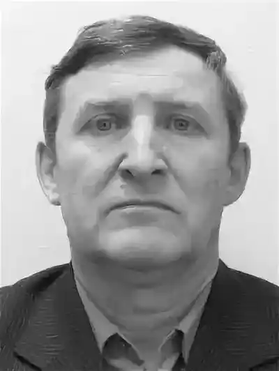

Горелов Сергей Витальевич — кандидат технических наук, доцент Департамента анализа данных, принятия решений и финансовых технологий Финансового университета при Правительстве Российской Федерации. Сфера интересов: современные технологии программирования, операционные системы, системы программирования, системы управления базами данных. Автор монографии и более 10 учебных пособий. Профессиональный разработчик программного обеспечения. В течение нескольких лет является разработчиком методических материалов для Всероссийской олимпиады школьников по информатике и Всероссийской олимпиады студентов и выпускников по профилю «информационные технологии», проводимых Финансовым университетом.

В учебнике даются основные сведения о теории и практике разработки Windows-приложений с графическим интерфейсом на языке C#. Книга состоит из двух томов. Во втором томе учебника излагаются сведения о разработке Windows-приложений с графическим интерфейсом на языке C# с применением сложных элементов управления и ряда технологий. Описываются способы табличного отображения данных с использованием сетки `DataGridView`. Рассмотрен режим привязки сетки к источнику данных, а также непривязанный и виртуальный режимы.

Для студентов, имеющих практические навыки разработки консольных приложений на языке C# и продолжающих его изучение для создания приложений с графическим интерфейсом. Материал учебника может быть полезен студентам при выполнении курсовых работ и творческих домашних заданий. Может быть интересен аспирантам, научным сотрудникам и преподавателям.

Страница 378